# ESC HW2

2015122016 김주연

2019년 3월 25일

# Q1

The Cautions for Regression Through Origin

$$\sum_{1}^{n}\left(y_{i}-\overline{y}\right)^{2} = \sum_{1}^{n}\left(y_{i}-\widehat{y_{i}}\right)^2 + \sum_{1}^{n}\left(\widehat{y_{i}}-\overline{y}\right)^{2} + 2\sum_{1}^{n}\left(y_{i}-\widehat{y_{i}}\right)\left(\widehat{y_{i}}-\overline{y}\right)$$

일반적인 constant를 포함한 linear regression model에서는 위의 공식에서 $\sum_{1}^{n}\left(y_{i}-\widehat{y_{i}}\right)\left(\widehat{y_{i}}-\overline{y}\right)$항이 0이 되기 때문에  
SSTO = SSE + SSR을 이용하여 $R^{2}$값을 구할 수 있다.  
하지만 constant가 없는 regression through origin model에서는 $\sum_{1}^{n}\left(y_{i}-\widehat{y_{i}}\right)\left(\widehat{y_{i}}-\overline{y}\right)$항이 0이 되지 않아  
$SSTO \neq SSE + SSR$이 되고, 일반적인 $R^{2}$ 공식을 사용할 수 없게 된다.  
특히 평균을 예측하는 것만으로도 오차가 충분히 작을 때 regression through origin model은 poor fitting을 하게 되고,  
$\sum_{1}^{n}\left(y_{i}-\overline{y}\right)^{2}$보다 $\sum_{1}^{n}\left(\widehat{y_{i}}-\overline{y}\right)^{2}$이 더 큰 값을 갖게 되어 $R^{2}$가 음수의 값을 갖게 된다.

# Q2

## Data Structure

```r
boston <- read.csv("file:///C:/Users/Lucy Jooyeon Kim/Desktop/ESC/2019-1/[Week 2] Assignment/dataset/boston.csv")

glimpse(boston)
```

```
## Observations: 506
## Variables: 14
## $ crim    <dbl> 0.00632, 0.02731, 0.02729, 0.03237, 0.06905, 0.02985, ...
## $ zn      <dbl> 18.0, 0.0, 0.0, 0.0, 0.0, 0.0, 12.5, 12.5, 12.5, 12.5,...
## $ indus   <dbl> 2.31, 7.07, 7.07, 2.18, 2.18, 2.18, 7.87, 7.87, 7.87, ...
## $ chas    <int> 0, 0, 0, 0, 0, 0, 0, 0, 0, 0, 0, 0, 0, 0, 0, 0, 0, 0, ...
## $ nox     <dbl> 0.538, 0.469, 0.469, 0.458, 0.458, 0.458, 0.524, 0.524...
## $ rm      <dbl> 6.575, 6.421, 7.185, 6.998, 7.147, 6.430, 6.012, 6.172...
## $ age     <dbl> 65.2, 78.9, 61.1, 45.8, 54.2, 58.7, 66.6, 96.1, 100.0,...
## $ dis     <dbl> 4.0900, 4.9671, 4.9671, 6.0622, 6.0622, 6.0622, 5.5605...
## $ rad     <int> 1, 2, 2, 3, 3, 3, 5, 5, 5, 5, 5, 5, 5, 4, 4, 4, 4, 4, ...
## $ tax     <int> 296, 242, 242, 222, 222, 222, 311, 311, 311, 311, 311,...
## $ ptratio <dbl> 15.3, 17.8, 17.8, 18.7, 18.7, 18.7, 15.2, 15.2, 15.2, ...
## $ black   <dbl> 396.90, 396.90, 392.83, 394.63, 396.90, 394.12, 395.60...
## $ lstat   <dbl> 4.98, 9.14, 4.03, 2.94, 5.33, 5.21, 12.43, 19.15, 29.9...
## $ medv    <dbl> 24.0, 21.6, 34.7, 33.4, 36.2, 28.7, 22.9, 27.1, 16.5, ...
```

```r
summary(boston)
```

```
##       crim                zn             indus            chas
##  Min.   : 0.00632   Min.   :  0.00   Min.   : 0.46   Min.   :0.00000
##  1st Qu.: 0.08204   1st Qu.:  0.00   1st Qu.: 5.19   1st Qu.:0.00000
##  Median : 0.25651   Median :  0.00   Median : 9.69   Median :0.00000
##  Mean   : 3.61352   Mean   : 11.36   Mean   :11.14   Mean   :0.06917
##  3rd Qu.: 3.67708   3rd Qu.: 12.50   3rd Qu.:18.10   3rd Qu.:0.00000
##  Max.   :88.97620   Max.   :100.00   Max.   :27.74   Max.   :1.00000
##       nox               rm             age              dis
##  Min.   :0.3850   Min.   :3.561   Min.   :  2.90   Min.   : 1.130
##  1st Qu.:0.4490   1st Qu.:5.886   1st Qu.: 45.02   1st Qu.: 2.100
##  Median :0.5380   Median :6.208   Median : 77.50   Median : 3.207
##  Mean   :0.5547   Mean   :6.285   Mean   : 68.57   Mean   : 3.795
##  3rd Qu.:0.6240   3rd Qu.:6.623   3rd Qu.: 94.08   3rd Qu.: 5.188
##  Max.   :0.8710   Max.   :8.780   Max.   :100.00   Max.   :12.127
##       rad              tax           ptratio          black
##  Min.   : 1.000   Min.   :187.0   Min.   :12.60   Min.   :  0.32
##  1st Qu.: 4.000   1st Qu.:279.0   1st Qu.:17.40   1st Qu.:375.38
##  Median : 5.000   Median :330.0   Median :19.05   Median :391.44
##  Mean   : 9.549   Mean   :408.2   Mean   :18.46   Mean   :356.67
##  3rd Qu.:24.000   3rd Qu.:666.0   3rd Qu.:20.20   3rd Qu.:396.23
##  Max.   :24.000   Max.   :711.0   Max.   :22.00   Max.   :396.90
##      lstat            medv
##  Min.   : 1.73   Min.   : 5.00
##  1st Qu.: 6.95   1st Qu.:17.02
##  Median :11.36   Median :21.20
##  Mean   :12.65   Mean   :22.53
##  3rd Qu.:16.95   3rd Qu.:25.00
##  Max.   :37.97   Max.   :50.00
```

## Check normality of response variable

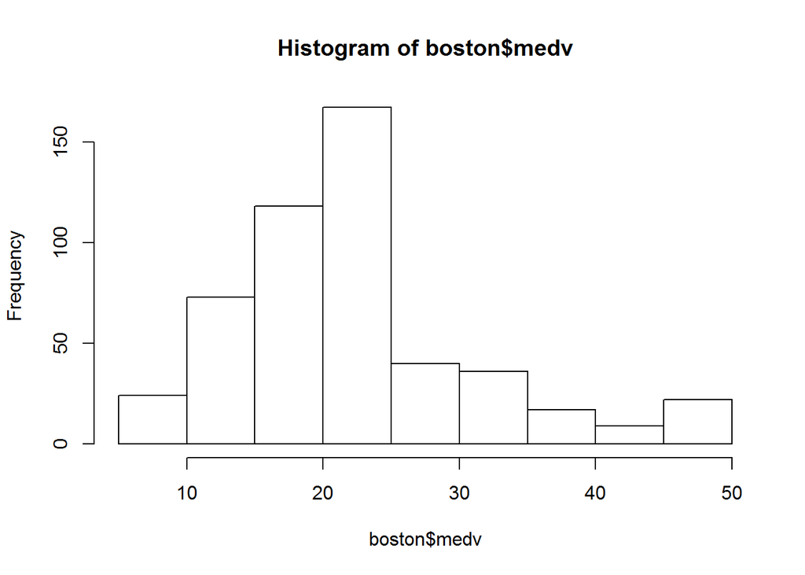

```r
hist(boston$medv)
```

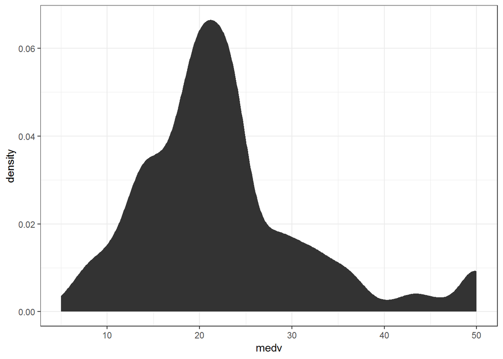

```r
boston %>% ggplot(aes(medv)) + stat_density() +  theme_bw()
```

약간 skewed된 것 같긴 하지만 roughly normal distribution을 따른다고 볼 수 있을 것 같다.

# EDA

```r
colSums(is.na(boston))
```

```
##    crim      zn   indus    chas     nox      rm     age     dis     rad
##       0       0       0       0       0       0       0       0       0
##     tax ptratio   black   lstat    medv
##       0       0       0       0       0
```

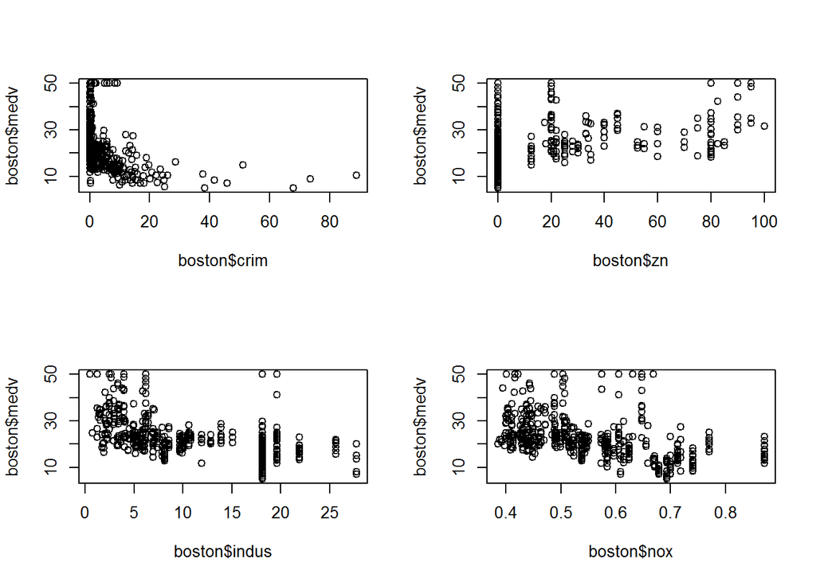

```r
par(mfrow=c(2,2))
plot(boston$crim, boston$medv)
plot(boston$zn, boston$medv)
plot(boston$indus, boston$medv)
plot(boston$nox, boston$medv)
```

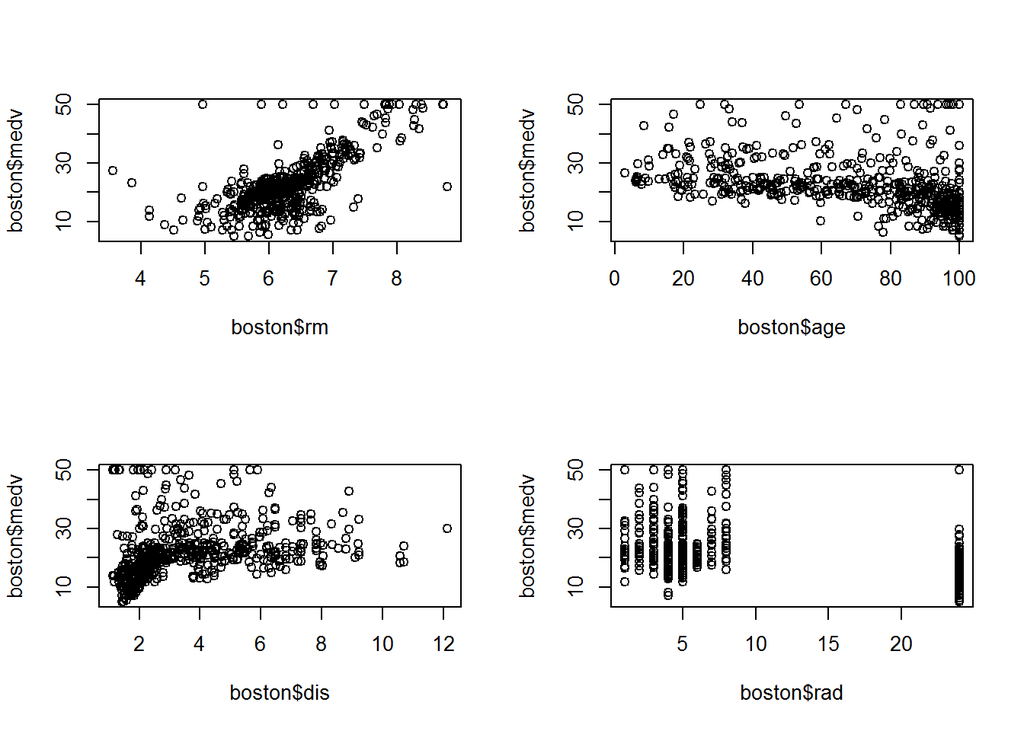

```r
plot(boston$rm, boston$medv)
plot(boston$age, boston$medv)
plot(boston$dis, boston$medv)
plot(boston$rad, boston$medv)
```

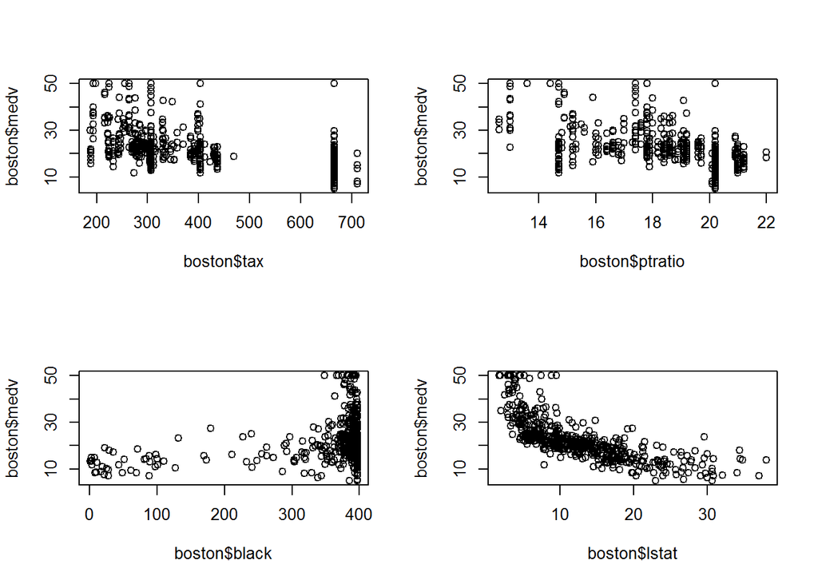

```r
plot(boston$tax, boston$medv)
plot(boston$ptratio, boston$medv)
plot(boston$black, boston$medv)
plot(boston$lstat, boston$medv)
```

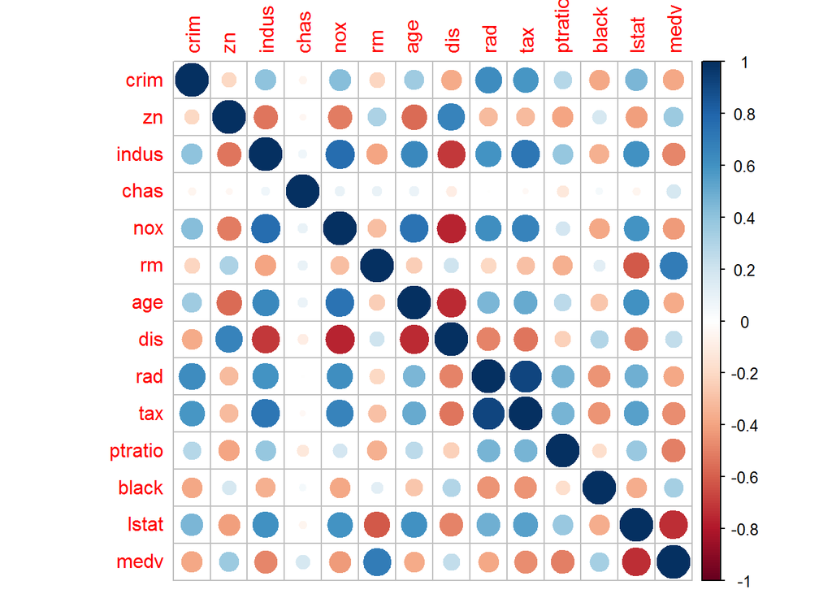

```r
par(mfrow=c(1,1))
corrplot(cor(boston))
```

```r
cor(boston$rad, boston$tax)
```

```
## [1] 0.9102282
```

```r
cor(boston$nox, boston$dis)
```

```
## [1] -0.7692301
```

```r
cor(boston$nox, boston$indus)
```

```
## [1] 0.7636514
```

```r
cor(boston$age, boston$dis)
```

```
## [1] -0.7478805
```

```r
cor(boston$nox, boston$age)
```

```
## [1] 0.7314701
```

```r
cor(boston$tax, boston$indus)
```

```
## [1] 0.7207602
```

```r
cor(boston$indus, boston$dis)
```

```
## [1] -0.708027
```

correlation coefficients가 0.7 이상인 설명변수들로 이들 사이에 다중공선성이 발생할 가능성이 높다고 판단.  
특히 rad와 tax 사이에 상당히 높은 선형적 관계가 있을 것으로 추정.

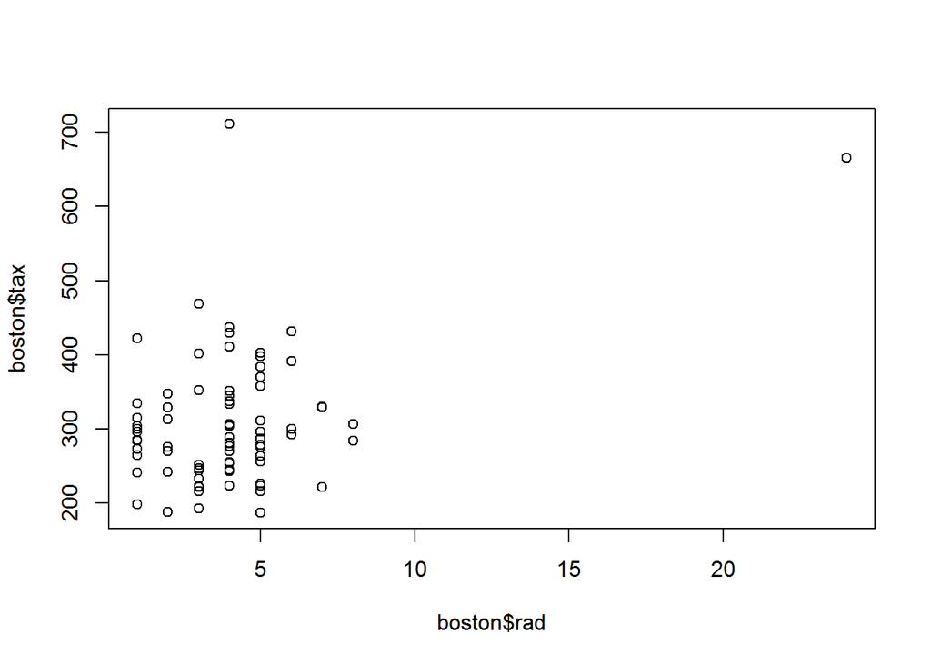

```r
plot(boston$rad, boston$tax)
```

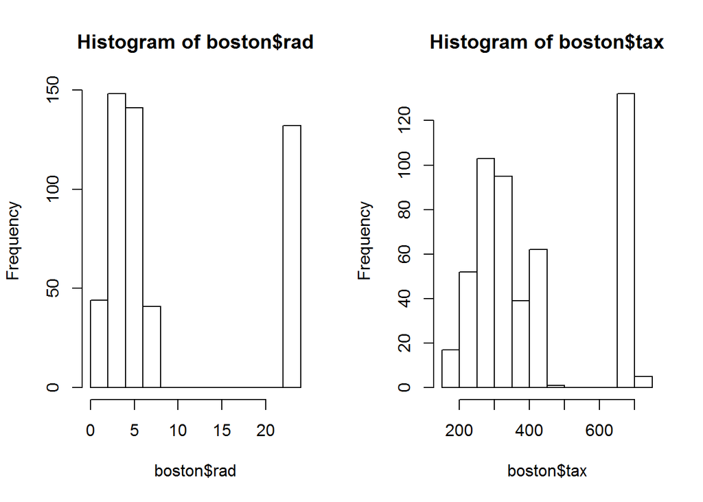

```r
par(mfrow=c(1,2))
hist(boston$rad)
hist(boston$tax)
```

rad와 tax 사이의 scatter plot을 그려보니 outlier에 의해 correlation이 발생하는 것으로 보여 histogram을 그려본 결과  
peak가 두 개인 data임을 확인할 수 있고, 이에 대한 처리가 필요할 것으로 보임.

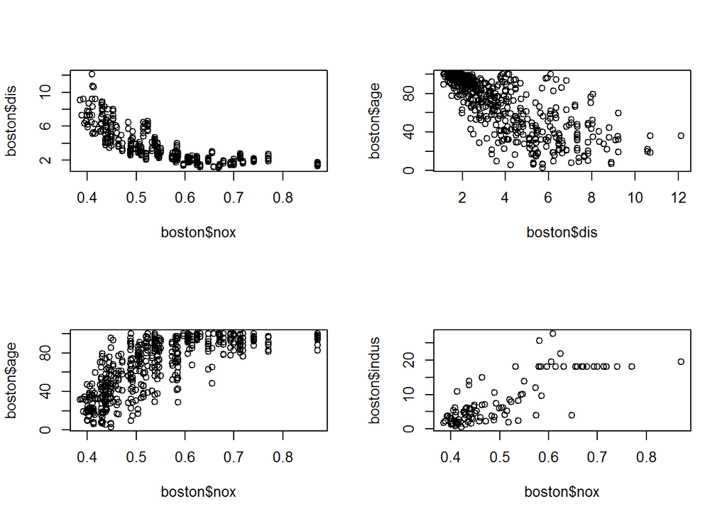

```r
par(mfrow=c(2,2))
plot(boston$nox, boston$dis)
plot(boston$dis, boston$age)
plot(boston$nox, boston$age)
plot(boston$nox, boston$indus)
```

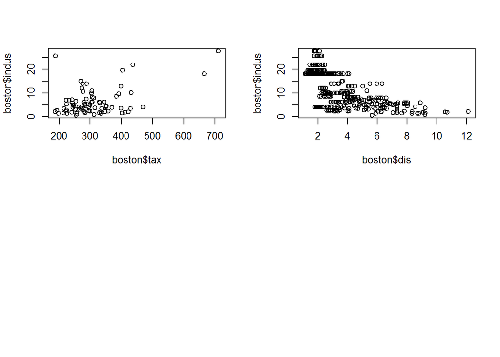

```r
plot(boston$tax, boston$indus)
plot(boston$dis, boston$indus)
```

nox, dis, tax, age, indus 사이에 어느 정도의 correlation이 있는 것으로 보이며, age와 indus는 nox, tax, dis 등으로 어느 정도 설명이 될 수 있을 것으로 판단됨.  
(역의 관계도 성립할 가능성 존재)

# full model

```r
full <- lm(medv ~ . , data=boston)
summary(full)
```

```
##
## Call:
## lm(formula = medv ~ ., data = boston)
##
## Residuals:
##     Min      1Q  Median      3Q     Max
## -15.595  -2.730  -0.518   1.777  26.199
##
## Coefficients:
##               Estimate Std. Error t value Pr(>|t|)
## (Intercept)  3.646e+01  5.103e+00   7.144 3.28e-12 ***
## crim        -1.080e-01  3.286e-02  -3.287 0.001087 **
## zn           4.642e-02  1.373e-02   3.382 0.000778 ***
## indus        2.056e-02  6.150e-02   0.334 0.738288
## chas         2.687e+00  8.616e-01   3.118 0.001925 **
## nox         -1.777e+01  3.820e+00  -4.651 4.25e-06 ***
## rm           3.810e+00  4.179e-01   9.116  < 2e-16 ***
## age          6.922e-04  1.321e-02   0.052 0.958229
## dis         -1.476e+00  1.995e-01  -7.398 6.01e-13 ***
## rad          3.060e-01  6.635e-02   4.613 5.07e-06 ***
## tax         -1.233e-02  3.760e-03  -3.280 0.001112 **
## ptratio     -9.527e-01  1.308e-01  -7.283 1.31e-12 ***
## black        9.312e-03  2.686e-03   3.467 0.000573 ***
## lstat       -5.248e-01  5.072e-02 -10.347  < 2e-16 ***
## ---
## Signif. codes:  0 '***' 0.001 '**' 0.01 '*' 0.05 '.' 0.1 ' ' 1
##
## Residual standard error: 4.745 on 492 degrees of freedom
## Multiple R-squared:  0.7406, Adjusted R-squared:  0.7338
## F-statistic: 108.1 on 13 and 492 DF,  p-value: < 2.2e-16
```

우선 모든 설명변수들을 넣고 full model을 만들어본 결과 indus와 age의 계수가 유의하지 않게 나왔음.

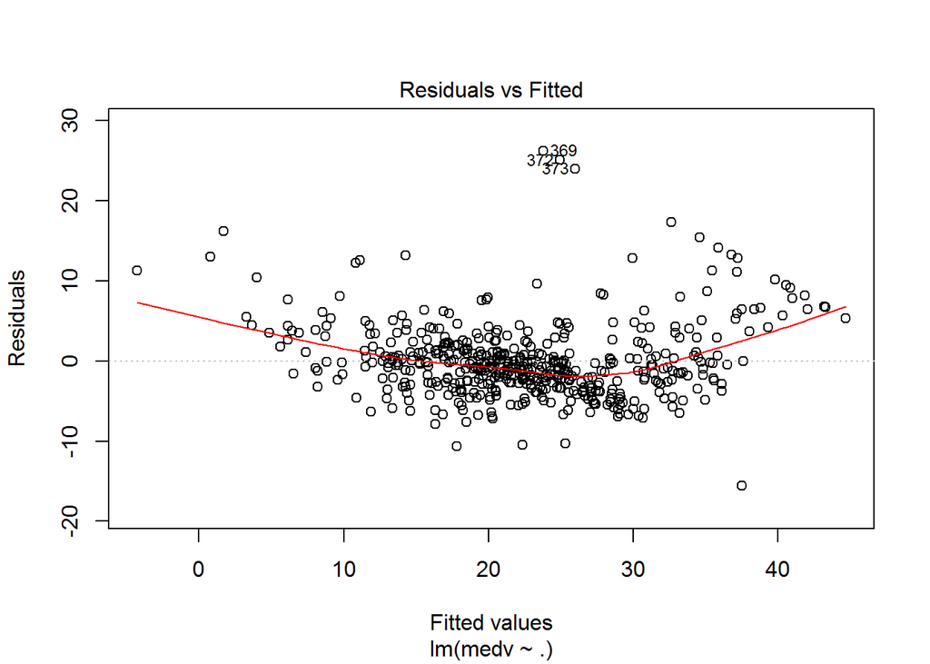

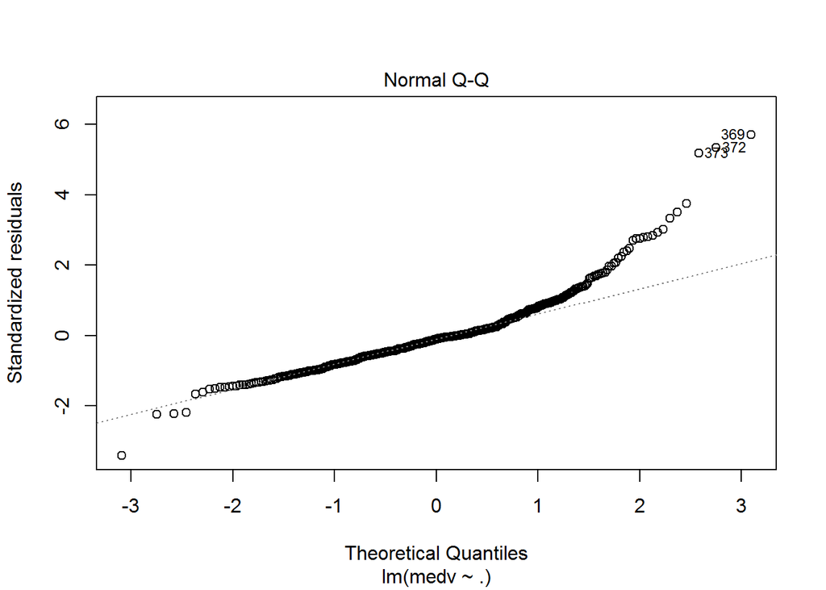

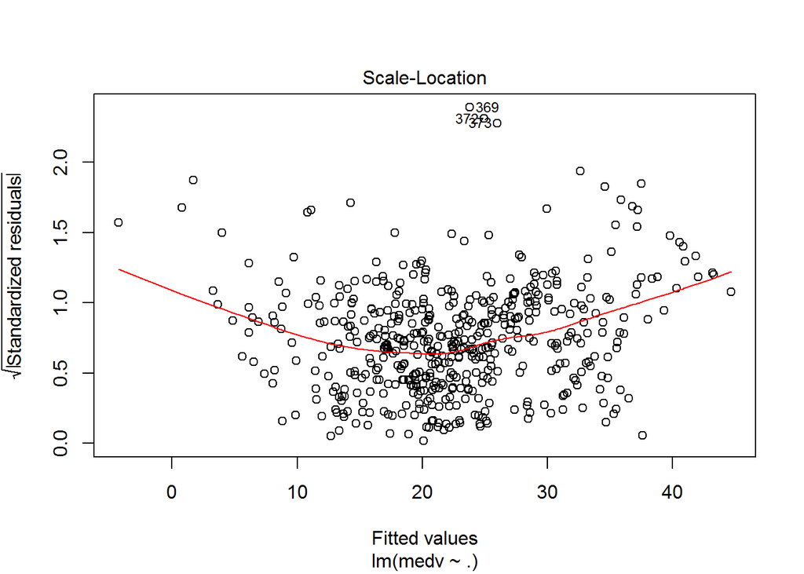

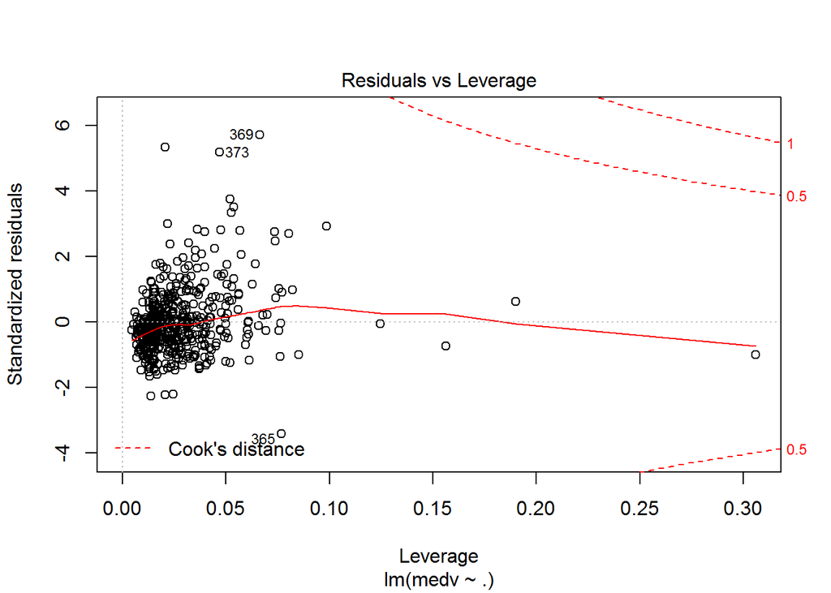

```r
plot(full)
```

```r
vif(full)
```

```
##     crim       zn    indus     chas      nox       rm      age      dis
## 1.792192 2.298758 3.991596 1.073995 4.393720 1.933744 3.100826 3.955945
##      rad      tax  ptratio    black    lstat
## 7.484496 9.008554 1.799084 1.348521 2.941491
```

```r
AIC(full) ; BIC(full)
```

```
## [1] 3027.609
```

```
## [1] 3091.007
```

# expected regression model

```r
boston2 <- boston[-c(369,372,373),]
exp.md <- lm(medv ~ .-indus-age, data=boston2)
summary(exp.md)
```

```
##
## Call:
## lm(formula = medv ~ . - indus - age, data = boston2)
##
## Residuals:
##      Min       1Q   Median       3Q      Max
## -14.9665  -2.4449  -0.5865   1.8231  19.8019
##
## Coefficients:
##               Estimate Std. Error t value Pr(>|t|)
## (Intercept)  30.313882   4.628785   6.549 1.46e-10 ***
## crim         -0.099061   0.029663  -3.340 0.000903 ***
## zn            0.039967   0.012243   3.265 0.001173 **
## chas          2.139794   0.783113   2.732 0.006514 **
## nox         -16.158058   3.199323  -5.050 6.22e-07 ***
## rm            4.488832   0.374820  11.976  < 2e-16 ***
## dis          -1.294912   0.169043  -7.660 9.97e-14 ***
## rad           0.251070   0.057538   4.364 1.56e-05 ***
## tax          -0.012243   0.003050  -4.014 6.92e-05 ***
## ptratio      -0.954242   0.116756  -8.173 2.58e-15 ***
## black         0.008678   0.002419   3.587 0.000368 ***
## lstat        -0.427210   0.043948  -9.721  < 2e-16 ***
## ---
## Signif. codes:  0 '***' 0.001 '**' 0.01 '*' 0.05 '.' 0.1 ' ' 1
##
## Residual standard error: 4.283 on 491 degrees of freedom
## Multiple R-squared:  0.7772, Adjusted R-squared:  0.7722
## F-statistic: 155.7 on 11 and 491 DF,  p-value: < 2.2e-16
```

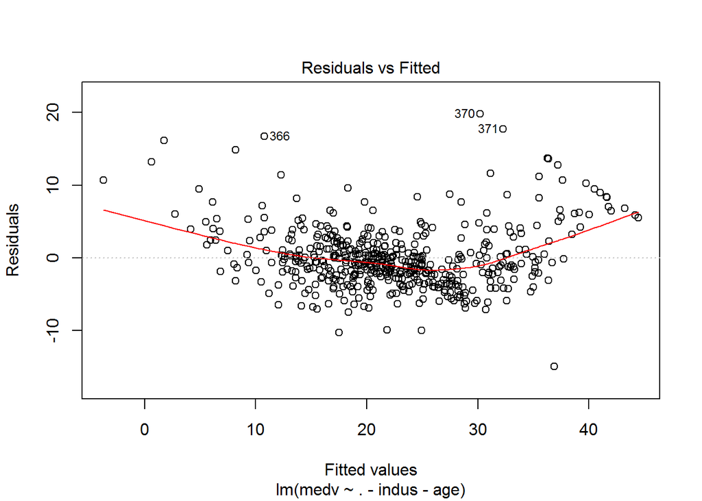

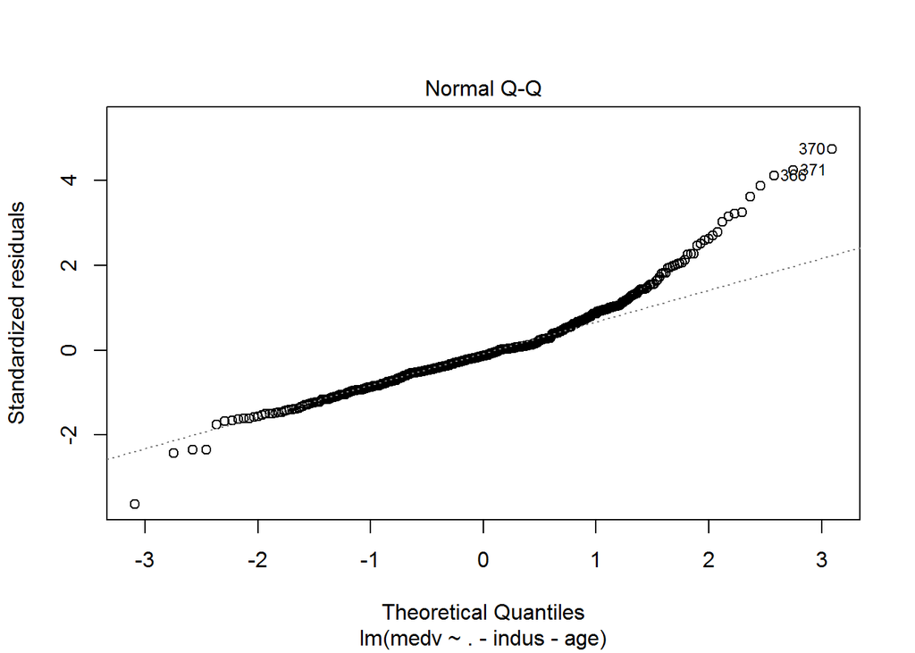

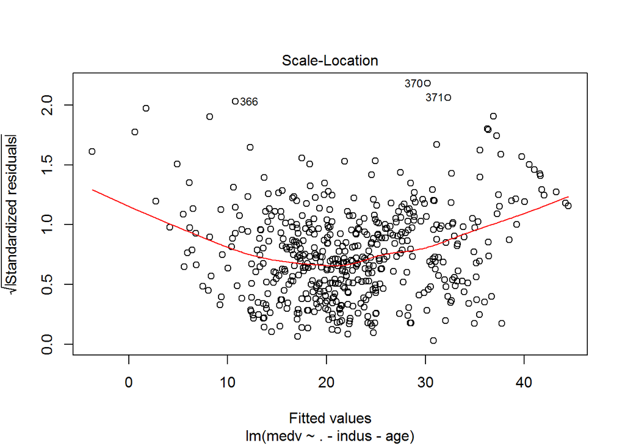

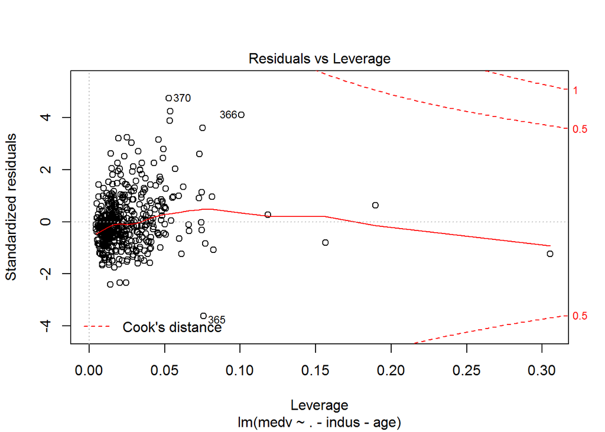

```r
plot(exp.md)
```

```r
vif(exp.md)
```

```
##     crim       zn     chas      nox       rm      dis      rad      tax
## 1.789230 2.240867 1.059664 3.769321 1.894416 3.456094 6.794954 7.173220
##  ptratio    black    lstat
## 1.751837 1.342510 2.699182
```

```r
AIC(exp.md) ; BIC(exp.md)
```

```
## [1] 2904.767
```

```
## [1] 2959.635
```

outlier로 예상되는 3개의 점을 제외하고, 유의하지 않았던 설명변수들을 빼서 regression model을 세워보았음.  
이 regression model과 variable selection으로 얻는 regression model을 비교해보고자 함.

위에서 언급했던 rad와 tax의 collinearity를 해결해보기 위해  
두 가지의 가능성을 시도해보았지만 적합하지 않다고 판단,  
outlier 3개를 제외한 data로 variable selection을 진행하기로 함.

## case1 - make them binary : worse

```r
boston_re <- boston
boston_re$taxhigh <- ifelse(boston_re$tax > 600, 1, 0)
boston_re$radhigh <- ifelse(boston_re$rad > 20, 1, 0)
summary(boston_re)
```

```
##       crim                zn             indus            chas
##  Min.   : 0.00632   Min.   :  0.00   Min.   : 0.46   Min.   :0.00000
##  1st Qu.: 0.08204   1st Qu.:  0.00   1st Qu.: 5.19   1st Qu.:0.00000
##  Median : 0.25651   Median :  0.00   Median : 9.69   Median :0.00000
##  Mean   : 3.61352   Mean   : 11.36   Mean   :11.14   Mean   :0.06917
##  3rd Qu.: 3.67708   3rd Qu.: 12.50   3rd Qu.:18.10   3rd Qu.:0.00000
##  Max.   :88.97620   Max.   :100.00   Max.   :27.74   Max.   :1.00000
##       nox               rm             age              dis
##  Min.   :0.3850   Min.   :3.561   Min.   :  2.90   Min.   : 1.130
##  1st Qu.:0.4490   1st Qu.:5.886   1st Qu.: 45.02   1st Qu.: 2.100
##  Median :0.5380   Median :6.208   Median : 77.50   Median : 3.207
##  Mean   :0.5547   Mean   :6.285   Mean   : 68.57   Mean   : 3.795
##  3rd Qu.:0.6240   3rd Qu.:6.623   3rd Qu.: 94.08   3rd Qu.: 5.188
##  Max.   :0.8710   Max.   :8.780   Max.   :100.00   Max.   :12.127
##       rad              tax           ptratio          black
##  Min.   : 1.000   Min.   :187.0   Min.   :12.60   Min.   :  0.32
##  1st Qu.: 4.000   1st Qu.:279.0   1st Qu.:17.40   1st Qu.:375.38
##  Median : 5.000   Median :330.0   Median :19.05   Median :391.44
##  Mean   : 9.549   Mean   :408.2   Mean   :18.46   Mean   :356.67
##  3rd Qu.:24.000   3rd Qu.:666.0   3rd Qu.:20.20   3rd Qu.:396.23
##  Max.   :24.000   Max.   :711.0   Max.   :22.00   Max.   :396.90
##      lstat            medv          taxhigh          radhigh
##  Min.   : 1.73   Min.   : 5.00   Min.   :0.0000   Min.   :0.0000
##  1st Qu.: 6.95   1st Qu.:17.02   1st Qu.:0.0000   1st Qu.:0.0000
##  Median :11.36   Median :21.20   Median :0.0000   Median :0.0000
##  Mean   :12.65   Mean   :22.53   Mean   :0.2708   Mean   :0.2609
##  3rd Qu.:16.95   3rd Qu.:25.00   3rd Qu.:1.0000   3rd Qu.:1.0000
##  Max.   :37.97   Max.   :50.00   Max.   :1.0000   Max.   :1.0000
```

```r
full.try1 <- lm(medv ~ .-indus-age-tax-rad, data=boston_re)
summary(full.try1)
```

```
##
## Call:
## lm(formula = medv ~ . - indus - age - tax - rad, data = boston_re)
##
## Residuals:
##      Min       1Q   Median       3Q      Max
## -16.2547  -2.9561  -0.4535   1.7212  26.4499
##
## Coefficients:
##               Estimate Std. Error t value Pr(>|t|)
## (Intercept)  34.468744   5.181173   6.653 7.65e-11 ***
## crim         -0.101770   0.033342  -3.052 0.002394 **
## zn            0.036253   0.013622   2.661 0.008037 **
## chas          2.985775   0.862907   3.460 0.000587 ***
## nox         -19.723795   3.471542  -5.682 2.28e-08 ***
## rm            4.009608   0.407846   9.831  < 2e-16 ***
## dis          -1.435100   0.188636  -7.608 1.42e-13 ***
## ptratio      -0.993201   0.132208  -7.512 2.74e-13 ***
## black         0.009584   0.002710   3.537 0.000443 ***
## lstat        -0.524445   0.048198 -10.881  < 2e-16 ***
## taxhigh      -2.100610   2.222145  -0.945 0.344964
## radhigh       4.284029   2.262432   1.894 0.058869 .
## ---
## Signif. codes:  0 '***' 0.001 '**' 0.01 '*' 0.05 '.' 0.1 ' ' 1
##
## Residual standard error: 4.801 on 494 degrees of freedom
## Multiple R-squared:  0.7335, Adjusted R-squared:  0.7275
## F-statistic: 123.6 on 11 and 494 DF,  p-value: < 2.2e-16
```

```r
vif(full.try1)
```

```
##      crim        zn      chas       nox        rm       dis   ptratio
##  1.802357  2.211831  1.052620  3.546014  1.799395  3.457337  1.795160
##     black     lstat   taxhigh   radhigh
##  1.340889  2.595801 21.406514 21.669588
```

## case2 - remove high values : BIAS

```r
boston_nohigh <- boston[-c(357:493),]
dim(boston_nohigh)[1]
```

```
## [1] 369
```

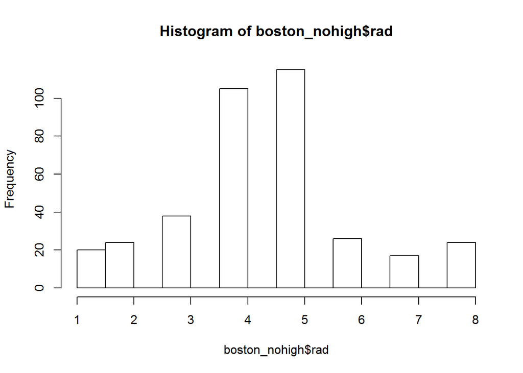

```r
hist(boston_nohigh$rad)
```

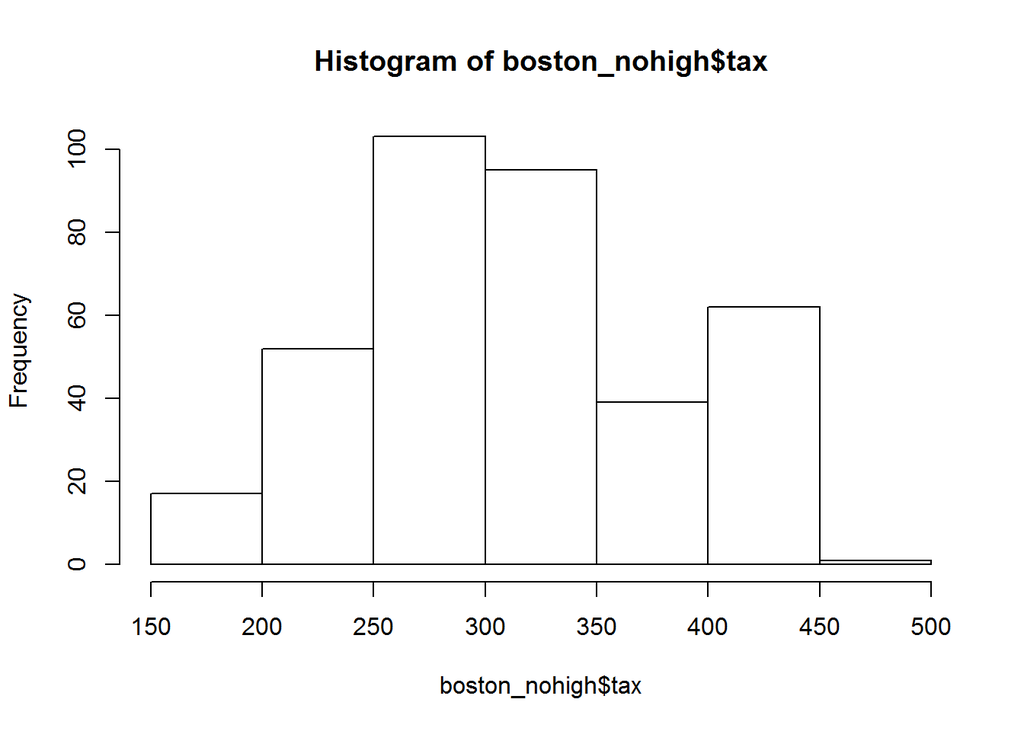

```r
hist(boston_nohigh$tax)
```

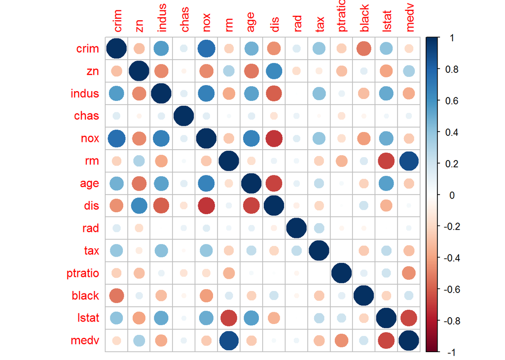

```r
corrplot(cor(boston_nohigh))
```

```r
full.try2 <- lm(medv ~ .-indus-age, data=boston_nohigh)
summary(full.try2)
```

```
##
## Call:
## lm(formula = medv ~ . - indus - age, data = boston_nohigh)
##
## Residuals:
##     Min      1Q  Median      3Q     Max
## -8.1198 -2.1233 -0.1371  1.7179 11.7478
##
## Coefficients:
##               Estimate Std. Error t value Pr(>|t|)
## (Intercept)  -9.529940   4.814351  -1.979 0.048529 *
## crim          1.257156   0.456086   2.756 0.006144 **
## zn            0.024848   0.009719   2.557 0.010983 *
## chas          0.752063   0.668193   1.126 0.261126
## nox         -12.231304   3.499468  -3.495 0.000533 ***
## rm            8.469279   0.377436  22.439  < 2e-16 ***
## dis          -0.764235   0.140158  -5.453 9.28e-08 ***
## rad           0.242695   0.110928   2.188 0.029328 *
## tax          -0.013491   0.002908  -4.639 4.92e-06 ***
## ptratio      -0.668939   0.094289  -7.095 7.02e-12 ***
## black         0.015448   0.005041   3.064 0.002347 **
## lstat        -0.176336   0.044634  -3.951 9.39e-05 ***
## ---
## Signif. codes:  0 '***' 0.001 '**' 0.01 '*' 0.05 '.' 0.1 ' ' 1
##
## Residual standard error: 3.24 on 357 degrees of freedom
## Multiple R-squared:  0.8538, Adjusted R-squared:  0.8493
## F-statistic: 189.5 on 11 and 357 DF,  p-value: < 2.2e-16
```

```r
vif(full.try2)
```

```
##     crim       zn     chas      nox       rm      dis      rad      tax
## 2.883342 2.254026 1.064642 4.401527 2.247906 3.031946 1.164909 1.364390
##  ptratio    black    lstat
## 1.522811 1.395031 2.375842
```

```r
AIC(full.try2) ; BIC(full.try2)
```

```
## [1] 1928.444
```

```
## [1] 1979.284
```

```r
dim(boston[boston$tax > 600,])[1]
```

```
## [1] 137
```

```r
dim(boston[boston$rad >20,])[1]
```

```
## [1] 132
```

```r
dim(boston)[1]
```

```
## [1] 506
```

## variable selection by leaps package

```r
regfit.fwd <- regsubsets(medv~.,boston2,nvmax=13,method='forward')
sum.fwd <- summary(regfit.fwd)
which.max(sum.fwd$adjr2)
```

```
## [1] 12
```

```r
which.min(sum.fwd$bic)
```

```
## [1] 11
```

```r
which.min(sum.fwd$cp)
```

```
## [1] 11
```

```r
sum.fwd
```

```
## Subset selection object
## Call: regsubsets.formula(medv ~ ., boston2, nvmax = 13, method = "forward")
## 13 Variables  (and intercept)
##         Forced in Forced out
## crim        FALSE      FALSE
## zn          FALSE      FALSE
## indus       FALSE      FALSE
## chas        FALSE      FALSE
## nox         FALSE      FALSE
## rm          FALSE      FALSE
## age         FALSE      FALSE
## dis         FALSE      FALSE
## rad         FALSE      FALSE
## tax         FALSE      FALSE
## ptratio     FALSE      FALSE
## black       FALSE      FALSE
## lstat       FALSE      FALSE
## 1 subsets of each size up to 13
## Selection Algorithm: forward
##           crim zn  indus chas nox rm  age dis rad tax ptratio black lstat
## 1  ( 1 )  " "  " " " "   " "  " " " " " " " " " " " " " "     " "   "*"
## 2  ( 1 )  " "  " " " "   " "  " " "*" " " " " " " " " " "     " "   "*"
## 3  ( 1 )  " "  " " " "   " "  " " "*" " " " " " " " " "*"     " "   "*"
## 4  ( 1 )  " "  " " " "   " "  " " "*" " " " " " " " " "*"     "*"   "*"
## 5  ( 1 )  " "  " " " "   " "  " " "*" " " "*" " " " " "*"     "*"   "*"
## 6  ( 1 )  " "  " " " "   " "  "*" "*" " " "*" " " " " "*"     "*"   "*"
## 7  ( 1 )  " "  " " " "   "*"  "*" "*" " " "*" " " " " "*"     "*"   "*"
## 8  ( 1 )  " "  "*" " "   "*"  "*" "*" " " "*" " " " " "*"     "*"   "*"
## 9  ( 1 )  "*"  "*" " "   "*"  "*" "*" " " "*" " " " " "*"     "*"   "*"
## 10  ( 1 ) "*"  "*" " "   "*"  "*" "*" " " "*" "*" " " "*"     "*"   "*"
## 11  ( 1 ) "*"  "*" " "   "*"  "*" "*" " " "*" "*" "*" "*"     "*"   "*"
## 12  ( 1 ) "*"  "*" " "   "*"  "*" "*" "*" "*" "*" "*" "*"     "*"   "*"
## 13  ( 1 ) "*"  "*" "*"   "*"  "*" "*" "*" "*" "*" "*" "*"     "*"   "*"
```

```r
red.fwd <- lm(medv ~ .-indus, data=boston2)
summary(red.fwd)
```

```
##
## Call:
## lm(formula = medv ~ . - indus, data = boston2)
##
## Residuals:
##      Min       1Q   Median       3Q      Max
## -15.1693  -2.4395  -0.5574   1.8215  20.0531
##
## Coefficients:
##               Estimate Std. Error t value Pr(>|t|)
## (Intercept)  29.815238   4.651638   6.410 3.43e-10 ***
## crim         -0.098824   0.029660  -3.332 0.000928 ***
## zn            0.038293   0.012341   3.103 0.002027 **
## chas          2.182120   0.784004   2.783 0.005589 **
## nox         -15.161014   3.332422  -4.550 6.79e-06 ***
## rm            4.581545   0.384698  11.909  < 2e-16 ***
## age          -0.012819   0.012008  -1.068 0.286251
## dis          -1.349000   0.176449  -7.645 1.11e-13 ***
## rad           0.245571   0.057760   4.252 2.54e-05 ***
## tax          -0.012134   0.003052  -3.976 8.05e-05 ***
## ptratio      -0.944218   0.117117  -8.062 5.79e-15 ***
## black         0.008837   0.002423   3.646 0.000294 ***
## lstat        -0.409243   0.047055  -8.697  < 2e-16 ***
## ---
## Signif. codes:  0 '***' 0.001 '**' 0.01 '*' 0.05 '.' 0.1 ' ' 1
##
## Residual standard error: 4.283 on 490 degrees of freedom
## Multiple R-squared:  0.7778, Adjusted R-squared:  0.7723
## F-statistic: 142.9 on 12 and 490 DF,  p-value: < 2.2e-16
```

```r
red.fwd <- lm(medv ~ .-age-indus, data=boston2)
summary(red.fwd)
```

```
##
## Call:
## lm(formula = medv ~ . - age - indus, data = boston2)
##
## Residuals:
##      Min       1Q   Median       3Q      Max
## -14.9665  -2.4449  -0.5865   1.8231  19.8019
##
## Coefficients:
##               Estimate Std. Error t value Pr(>|t|)
## (Intercept)  30.313882   4.628785   6.549 1.46e-10 ***
## crim         -0.099061   0.029663  -3.340 0.000903 ***
## zn            0.039967   0.012243   3.265 0.001173 **
## chas          2.139794   0.783113   2.732 0.006514 **
## nox         -16.158058   3.199323  -5.050 6.22e-07 ***
## rm            4.488832   0.374820  11.976  < 2e-16 ***
## dis          -1.294912   0.169043  -7.660 9.97e-14 ***
## rad           0.251070   0.057538   4.364 1.56e-05 ***
## tax          -0.012243   0.003050  -4.014 6.92e-05 ***
## ptratio      -0.954242   0.116756  -8.173 2.58e-15 ***
## black         0.008678   0.002419   3.587 0.000368 ***
## lstat        -0.427210   0.043948  -9.721  < 2e-16 ***
## ---
## Signif. codes:  0 '***' 0.001 '**' 0.01 '*' 0.05 '.' 0.1 ' ' 1
##
## Residual standard error: 4.283 on 491 degrees of freedom
## Multiple R-squared:  0.7772, Adjusted R-squared:  0.7722
## F-statistic: 155.7 on 11 and 491 DF,  p-value: < 2.2e-16
```

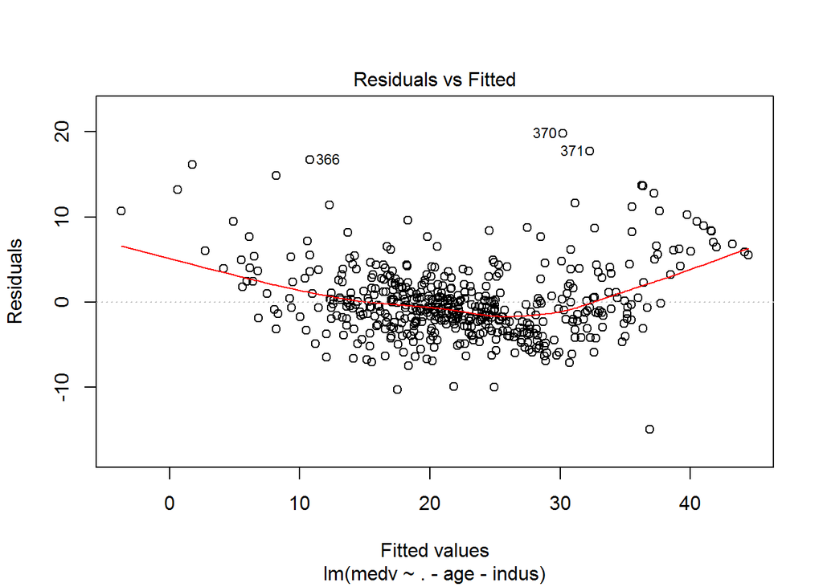

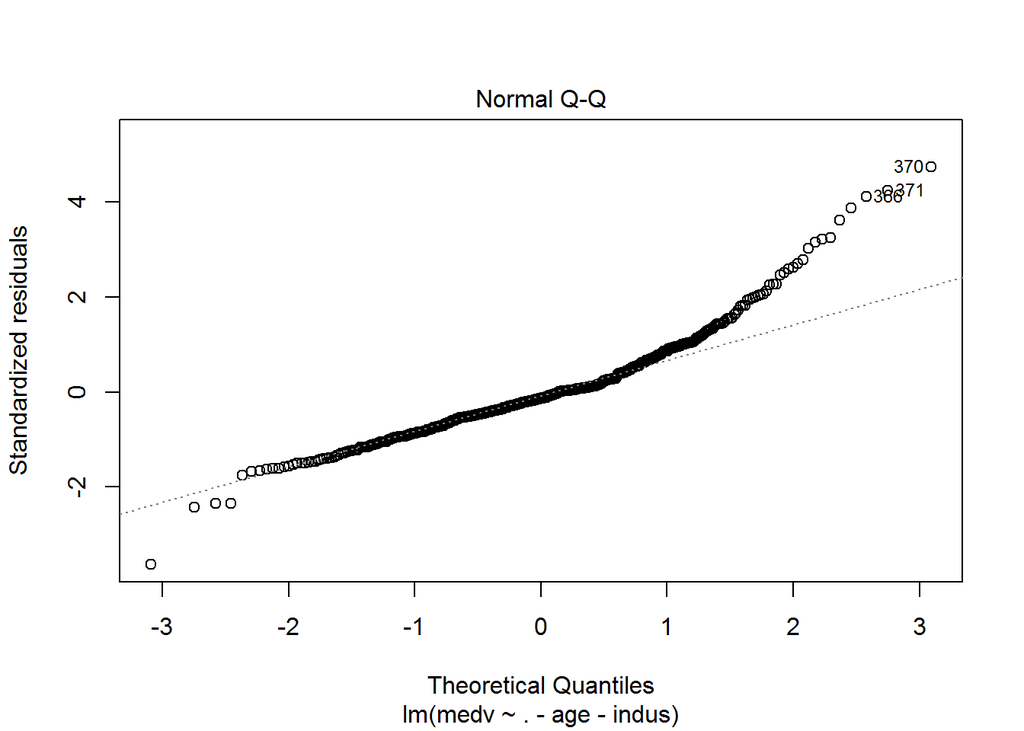

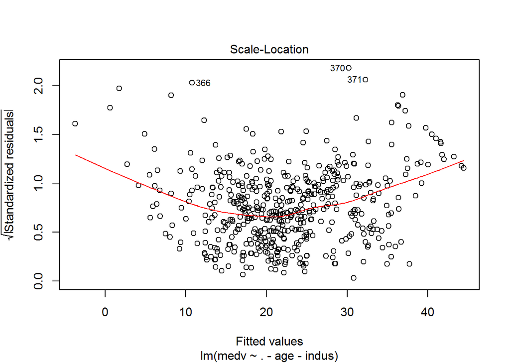

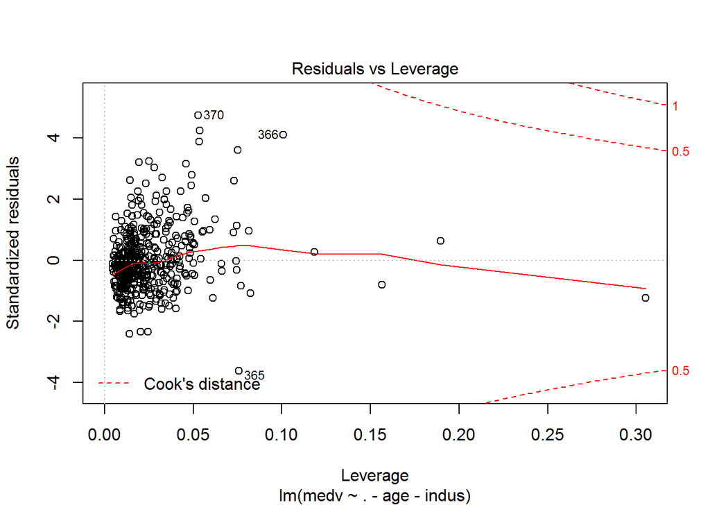

```r
plot(red.fwd)
```

```r
vif(red.fwd)
```

```
##     crim       zn     chas      nox       rm      dis      rad      tax
## 1.789230 2.240867 1.059664 3.769321 1.894416 3.456094 6.794954 7.173220
##  ptratio    black    lstat
## 1.751837 1.342510 2.699182
```

```r
AIC(red.fwd) ; BIC(red.fwd)
```

```
## [1] 2904.767
```

```
## [1] 2959.635
```

```r
regfit.bk <- regsubsets(medv~.,boston2,nvmax=13,method='backward')
sum.bk <- summary(regfit.bk)
which.max(sum.bk$adjr2)
```

```
## [1] 12
```

```r
which.min(sum.bk$bic)
```

```
## [1] 11
```

```r
which.min(sum.bk$cp)
```

```
## [1] 11
```

```r
sum.bk
```

```
## Subset selection object
## Call: regsubsets.formula(medv ~ ., boston2, nvmax = 13, method = "backward")
## 13 Variables  (and intercept)
##         Forced in Forced out
## crim        FALSE      FALSE
## zn          FALSE      FALSE
## indus       FALSE      FALSE
## chas        FALSE      FALSE
## nox         FALSE      FALSE
## rm          FALSE      FALSE
## age         FALSE      FALSE
## dis         FALSE      FALSE
## rad         FALSE      FALSE
## tax         FALSE      FALSE
## ptratio     FALSE      FALSE
## black       FALSE      FALSE
## lstat       FALSE      FALSE
## 1 subsets of each size up to 13
## Selection Algorithm: backward
##           crim zn  indus chas nox rm  age dis rad tax ptratio black lstat
## 1  ( 1 )  " "  " " " "   " "  " " " " " " " " " " " " " "     " "   "*"
## 2  ( 1 )  " "  " " " "   " "  " " "*" " " " " " " " " " "     " "   "*"
## 3  ( 1 )  " "  " " " "   " "  " " "*" " " " " " " " " "*"     " "   "*"
## 4  ( 1 )  " "  " " " "   " "  " " "*" " " "*" " " " " "*"     " "   "*"
## 5  ( 1 )  " "  " " " "   " "  "*" "*" " " "*" " " " " "*"     " "   "*"
## 6  ( 1 )  " "  " " " "   " "  "*" "*" " " "*" " " " " "*"     "*"   "*"
## 7  ( 1 )  " "  " " " "   " "  "*" "*" " " "*" " " "*" "*"     "*"   "*"
## 8  ( 1 )  " "  " " " "   " "  "*" "*" " " "*" "*" "*" "*"     "*"   "*"
## 9  ( 1 )  "*"  " " " "   " "  "*" "*" " " "*" "*" "*" "*"     "*"   "*"
## 10  ( 1 ) "*"  "*" " "   " "  "*" "*" " " "*" "*" "*" "*"     "*"   "*"
## 11  ( 1 ) "*"  "*" " "   "*"  "*" "*" " " "*" "*" "*" "*"     "*"   "*"
## 12  ( 1 ) "*"  "*" " "   "*"  "*" "*" "*" "*" "*" "*" "*"     "*"   "*"
## 13  ( 1 ) "*"  "*" "*"   "*"  "*" "*" "*" "*" "*" "*" "*"     "*"   "*"
```

```r
red.bk <- lm(medv ~ .-indus-age, data=boston2)
summary(red.bk)
```

```
##
## Call:
## lm(formula = medv ~ . - indus - age, data = boston2)
##
## Residuals:
##      Min       1Q   Median       3Q      Max
## -14.9665  -2.4449  -0.5865   1.8231  19.8019
##
## Coefficients:
##               Estimate Std. Error t value Pr(>|t|)
## (Intercept)  30.313882   4.628785   6.549 1.46e-10 ***
## crim         -0.099061   0.029663  -3.340 0.000903 ***
## zn            0.039967   0.012243   3.265 0.001173 **
## chas          2.139794   0.783113   2.732 0.006514 **
## nox         -16.158058   3.199323  -5.050 6.22e-07 ***
## rm            4.488832   0.374820  11.976  < 2e-16 ***
## dis          -1.294912   0.169043  -7.660 9.97e-14 ***
## rad           0.251070   0.057538   4.364 1.56e-05 ***
## tax          -0.012243   0.003050  -4.014 6.92e-05 ***
## ptratio      -0.954242   0.116756  -8.173 2.58e-15 ***
## black         0.008678   0.002419   3.587 0.000368 ***
## lstat        -0.427210   0.043948  -9.721  < 2e-16 ***
## ---
## Signif. codes:  0 '***' 0.001 '**' 0.01 '*' 0.05 '.' 0.1 ' ' 1
##
## Residual standard error: 4.283 on 491 degrees of freedom
## Multiple R-squared:  0.7772, Adjusted R-squared:  0.7722
## F-statistic: 155.7 on 11 and 491 DF,  p-value: < 2.2e-16
```

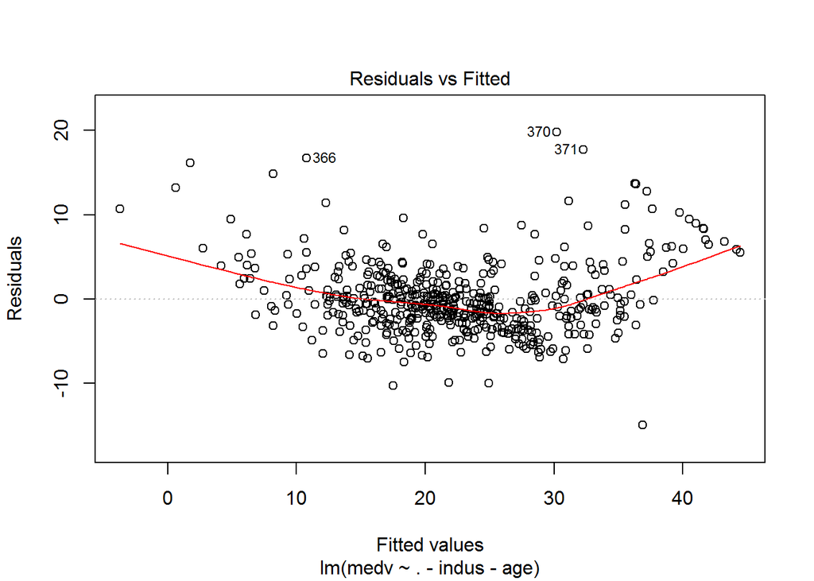

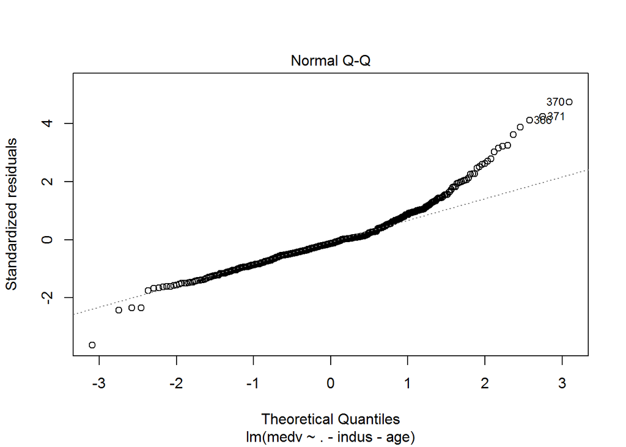

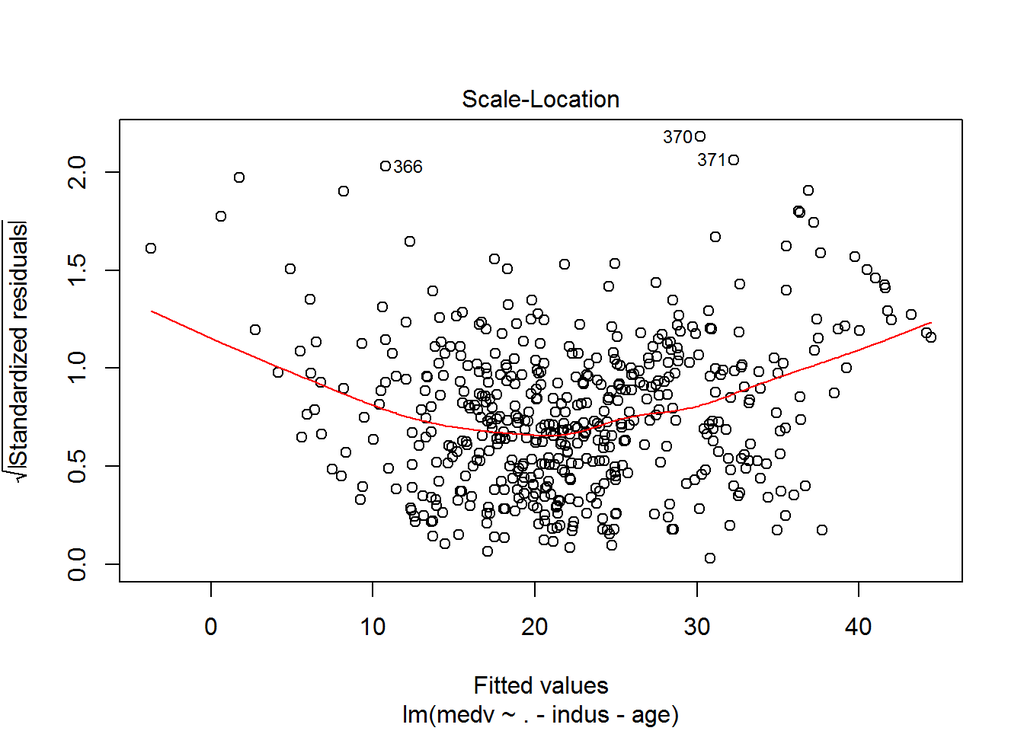

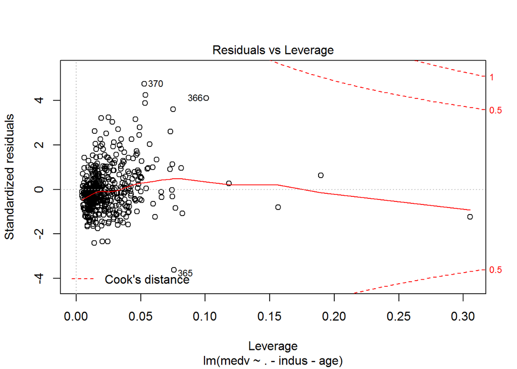

```r
plot(red.bk)
```

```r
vif(red.bk)
```

```
##     crim       zn     chas      nox       rm      dis      rad      tax
## 1.789230 2.240867 1.059664 3.769321 1.894416 3.456094 6.794954 7.173220
##  ptratio    black    lstat
## 1.751837 1.342510 2.699182
```

```r
AIC(red.bk) ; BIC(red.bk)
```

```
## [1] 2904.767
```

```
## [1] 2959.635
```

```r
regfit.sw <- regsubsets(medv~.,boston2,nvmax=13,method='seqrep')
sum.sw <- summary(regfit.sw)
which.max(sum.sw$adjr2)
```

```
## [1] 12
```

```r
which.min(sum.sw$bic)
```

```
## [1] 10
```

```r
which.min(sum.sw$cp)
```

```
## [1] 12
```

```r
sum.sw
```

```
## Subset selection object
## Call: regsubsets.formula(medv ~ ., boston2, nvmax = 13, method = "seqrep")
## 13 Variables  (and intercept)
##         Forced in Forced out
## crim        FALSE      FALSE
## zn          FALSE      FALSE
## indus       FALSE      FALSE
## chas        FALSE      FALSE
## nox         FALSE      FALSE
## rm          FALSE      FALSE
## age         FALSE      FALSE
## dis         FALSE      FALSE
## rad         FALSE      FALSE
## tax         FALSE      FALSE
## ptratio     FALSE      FALSE
## black       FALSE      FALSE
## lstat       FALSE      FALSE
## 1 subsets of each size up to 13
## Selection Algorithm: 'sequential replacement'
##           crim zn  indus chas nox rm  age dis rad tax ptratio black lstat
## 1  ( 1 )  " "  " " " "   " "  " " " " " " " " " " " " " "     " "   "*"
## 2  ( 1 )  " "  " " " "   " "  " " "*" " " " " " " " " " "     " "   "*"
## 3  ( 1 )  " "  " " " "   " "  " " "*" " " " " " " " " "*"     " "   "*"
## 4  ( 1 )  " "  " " " "   " "  " " "*" " " " " " " " " "*"     "*"   "*"
## 5  ( 1 )  " "  " " " "   " "  "*" "*" " " "*" " " " " "*"     " "   "*"
## 6  ( 1 )  "*"  "*" "*"   "*"  "*" "*" " " " " " " " " " "     " "   " "
## 7  ( 1 )  " "  " " " "   "*"  "*" "*" " " "*" " " " " "*"     "*"   "*"
## 8  ( 1 )  " "  "*" " "   "*"  "*" "*" " " "*" " " " " "*"     "*"   "*"
## 9  ( 1 )  "*"  "*" "*"   "*"  "*" "*" "*" "*" "*" " " " "     " "   " "
## 10  ( 1 ) "*"  "*" " "   " "  "*" "*" " " "*" "*" "*" "*"     "*"   "*"
## 11  ( 1 ) "*"  "*" "*"   "*"  "*" "*" "*" "*" "*" "*" "*"     " "   " "
## 12  ( 1 ) "*"  "*" " "   "*"  "*" "*" "*" "*" "*" "*" "*"     "*"   "*"
## 13  ( 1 ) "*"  "*" "*"   "*"  "*" "*" "*" "*" "*" "*" "*"     "*"   "*"
```

```r
red.sw2 <- lm(medv ~ .-indus-age-chas, data=boston2)
summary(red.sw2)
```

```
##
## Call:
## lm(formula = medv ~ . - indus - age - chas, data = boston2)
##
## Residuals:
##      Min       1Q   Median       3Q      Max
## -13.2033  -2.4702  -0.5811   1.8275  21.7003
##
## Coefficients:
##               Estimate Std. Error t value Pr(>|t|)
## (Intercept)  30.472276   4.658738   6.541 1.54e-10 ***
## crim         -0.103351   0.029815  -3.466 0.000574 ***
## zn            0.039772   0.012323   3.228 0.001332 **
## nox         -15.447636   3.209627  -4.813 1.98e-06 ***
## rm            4.530890   0.376957  12.020  < 2e-16 ***
## dis          -1.318195   0.169934  -7.757 5.05e-14 ***
## rad           0.262785   0.057754   4.550 6.76e-06 ***
## tax          -0.012948   0.003059  -4.232 2.76e-05 ***
## ptratio      -0.979814   0.117143  -8.364 6.28e-16 ***
## black         0.009013   0.002432   3.706 0.000234 ***
## lstat        -0.430161   0.044223  -9.727  < 2e-16 ***
## ---
## Signif. codes:  0 '***' 0.001 '**' 0.01 '*' 0.05 '.' 0.1 ' ' 1
##
## Residual standard error: 4.311 on 492 degrees of freedom
## Multiple R-squared:  0.7739, Adjusted R-squared:  0.7693
## F-statistic: 168.4 on 10 and 492 DF,  p-value: < 2.2e-16
```

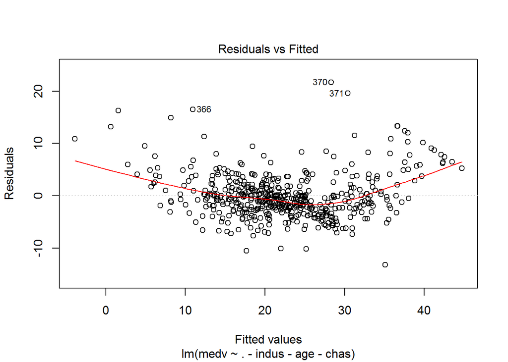

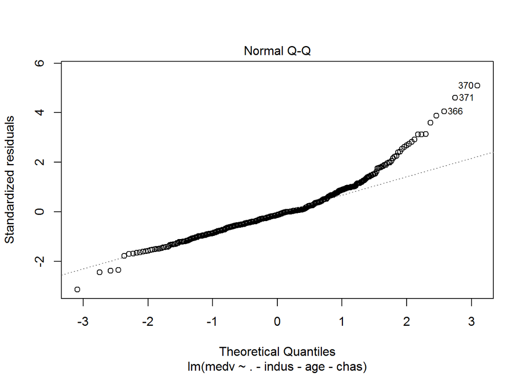

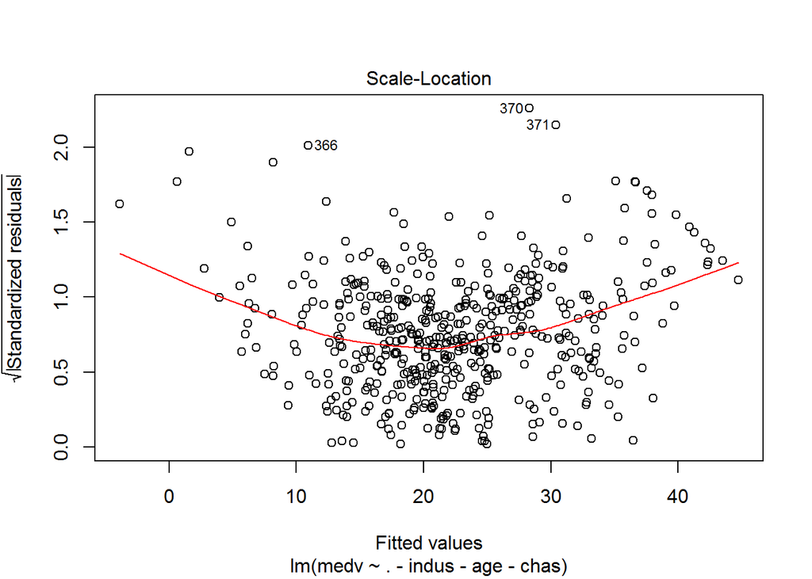

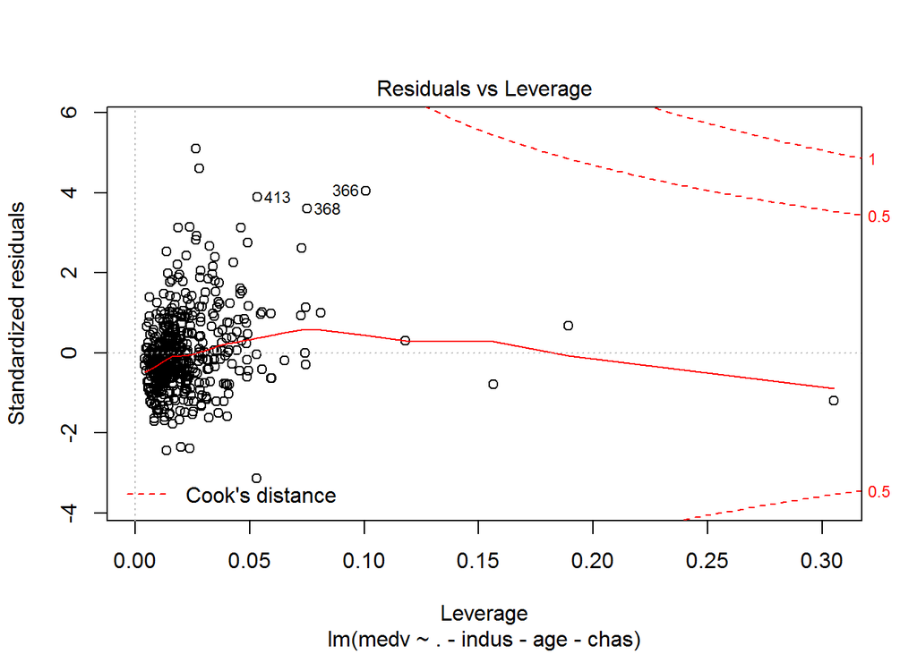

```r
plot(red.sw2)
```

```r
vif(red.sw2)
```

```
##     crim       zn      nox       rm      dis      rad      tax  ptratio
## 1.784216 2.240791 3.744428 1.891222 3.447312 6.757229 7.121810 1.740581
##    black    lstat
## 1.339051 2.697552
```

```r
AIC(red.sw2) ; BIC(red.sw2)
```

```
## [1] 2910.358
```

```
## [1] 2961.005
```

# variable selection by MASS package

```r
null <- lm(medv ~ 1, data=boston2)

fwd.model <- stepAIC(null, direction = "forward", trace = FALSE,
                     scope=list(upper=full,lower=null))
summary(fwd.model)
```

```
##
## Call:
## lm(formula = medv ~ lstat + rm + ptratio + black + dis + nox +
##     chas + zn + crim + rad + tax, data = boston2)
##
## Residuals:
##      Min       1Q   Median       3Q      Max
## -14.9665  -2.4449  -0.5865   1.8231  19.8019
##
## Coefficients:
##               Estimate Std. Error t value Pr(>|t|)
## (Intercept)  30.313882   4.628785   6.549 1.46e-10 ***
## lstat        -0.427210   0.043948  -9.721  < 2e-16 ***
## rm            4.488832   0.374820  11.976  < 2e-16 ***
## ptratio      -0.954242   0.116756  -8.173 2.58e-15 ***
## black         0.008678   0.002419   3.587 0.000368 ***
## dis          -1.294912   0.169043  -7.660 9.97e-14 ***
## nox         -16.158058   3.199323  -5.050 6.22e-07 ***
## chas          2.139794   0.783113   2.732 0.006514 **
## zn            0.039967   0.012243   3.265 0.001173 **
## crim         -0.099061   0.029663  -3.340 0.000903 ***
## rad           0.251070   0.057538   4.364 1.56e-05 ***
## tax          -0.012243   0.003050  -4.014 6.92e-05 ***
## ---
## Signif. codes:  0 '***' 0.001 '**' 0.01 '*' 0.05 '.' 0.1 ' ' 1
##
## Residual standard error: 4.283 on 491 degrees of freedom
## Multiple R-squared:  0.7772, Adjusted R-squared:  0.7722
## F-statistic: 155.7 on 11 and 491 DF,  p-value: < 2.2e-16
```

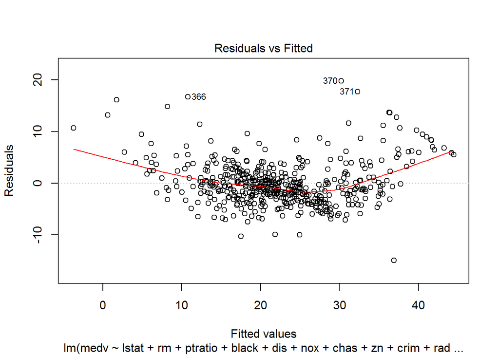

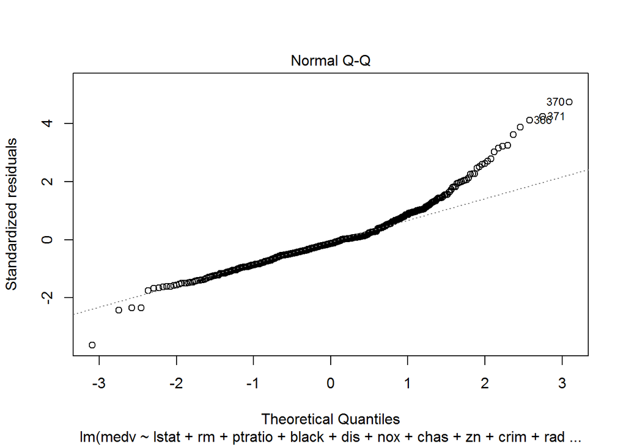

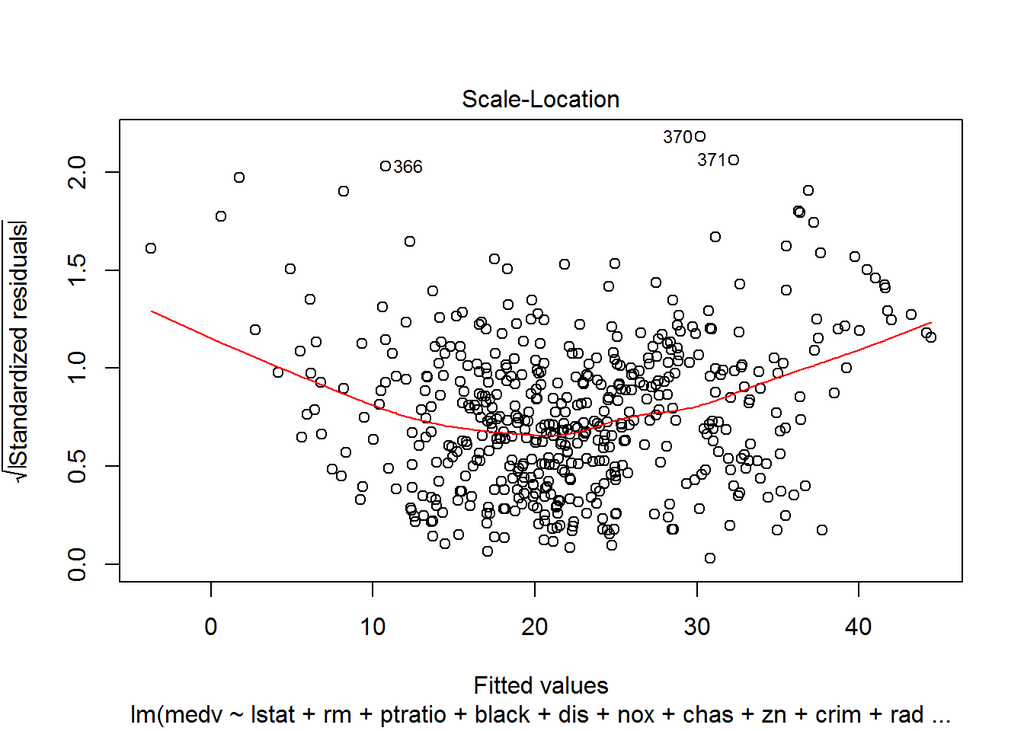

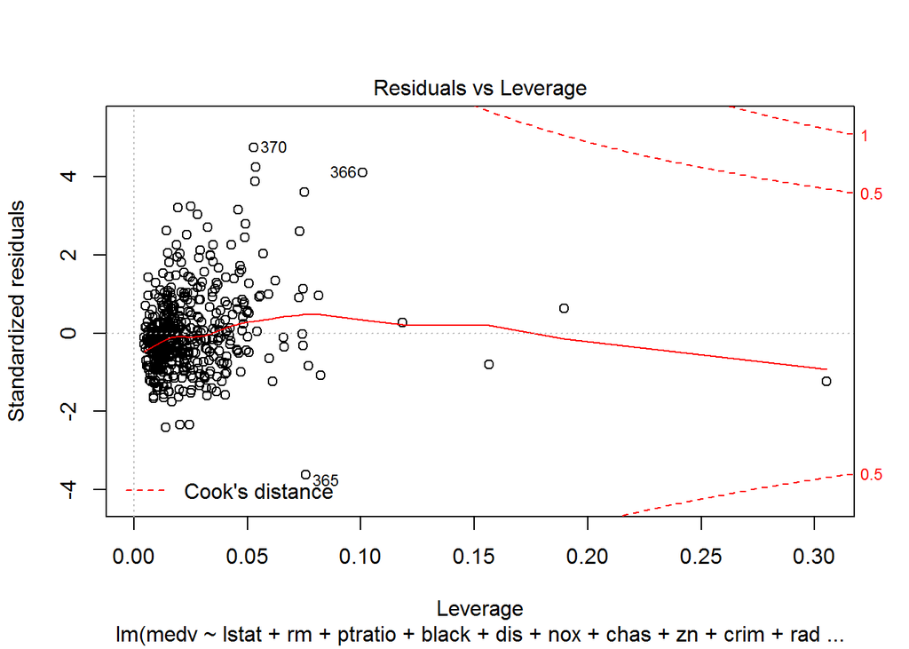

```r
plot(fwd.model)
```

```r
vif(fwd.model)
```

```
##    lstat       rm  ptratio    black      dis      nox     chas       zn
## 2.699182 1.894416 1.751837 1.342510 3.456094 3.769321 1.059664 2.240867
##     crim      rad      tax
## 1.789230 6.794954 7.173220
```

```r
AIC(fwd.model) ; BIC(fwd.model)
```

```
## [1] 2904.767
```

```
## [1] 2959.635
```

```r
full <- lm(medv ~ ., data=boston2)

bk.model <- stepAIC(full, direction = "backward", trace = FALSE)
summary(bk.model)
```

```
##
## Call:
## lm(formula = medv ~ crim + zn + chas + nox + rm + dis + rad +
##     tax + ptratio + black + lstat, data = boston2)
##
## Residuals:
##      Min       1Q   Median       3Q      Max
## -14.9665  -2.4449  -0.5865   1.8231  19.8019
##
## Coefficients:
##               Estimate Std. Error t value Pr(>|t|)
## (Intercept)  30.313882   4.628785   6.549 1.46e-10 ***
## crim         -0.099061   0.029663  -3.340 0.000903 ***
## zn            0.039967   0.012243   3.265 0.001173 **
## chas          2.139794   0.783113   2.732 0.006514 **
## nox         -16.158058   3.199323  -5.050 6.22e-07 ***
## rm            4.488832   0.374820  11.976  < 2e-16 ***
## dis          -1.294912   0.169043  -7.660 9.97e-14 ***
## rad           0.251070   0.057538   4.364 1.56e-05 ***
## tax          -0.012243   0.003050  -4.014 6.92e-05 ***
## ptratio      -0.954242   0.116756  -8.173 2.58e-15 ***
## black         0.008678   0.002419   3.587 0.000368 ***
## lstat        -0.427210   0.043948  -9.721  < 2e-16 ***
## ---
## Signif. codes:  0 '***' 0.001 '**' 0.01 '*' 0.05 '.' 0.1 ' ' 1
##
## Residual standard error: 4.283 on 491 degrees of freedom
## Multiple R-squared:  0.7772, Adjusted R-squared:  0.7722
## F-statistic: 155.7 on 11 and 491 DF,  p-value: < 2.2e-16
```

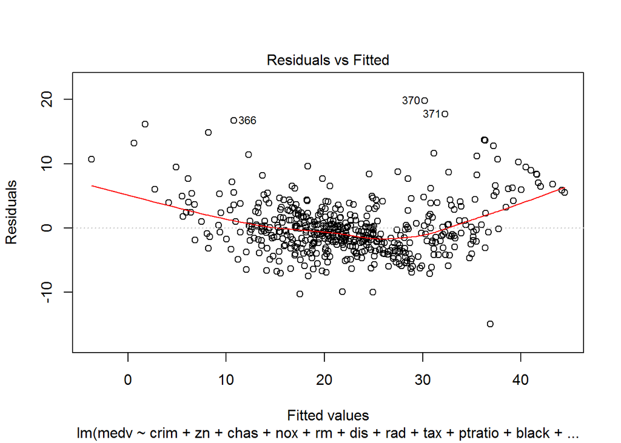

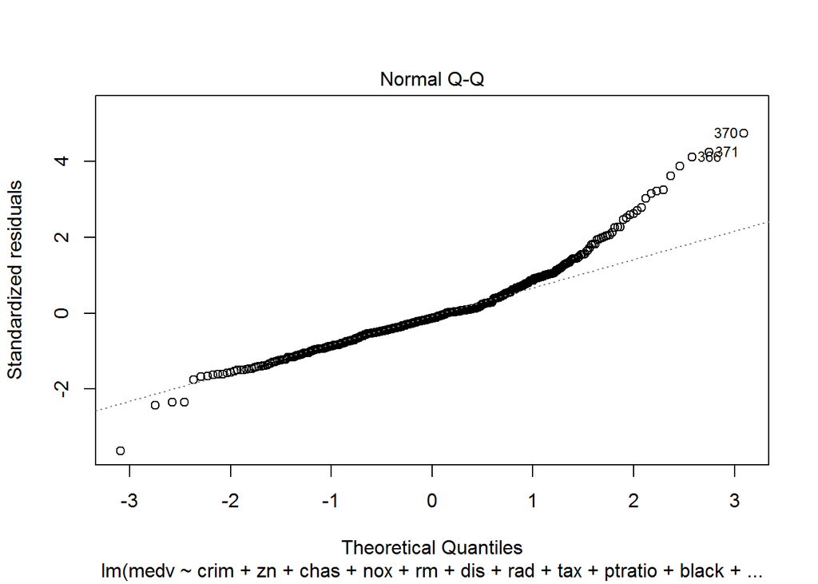

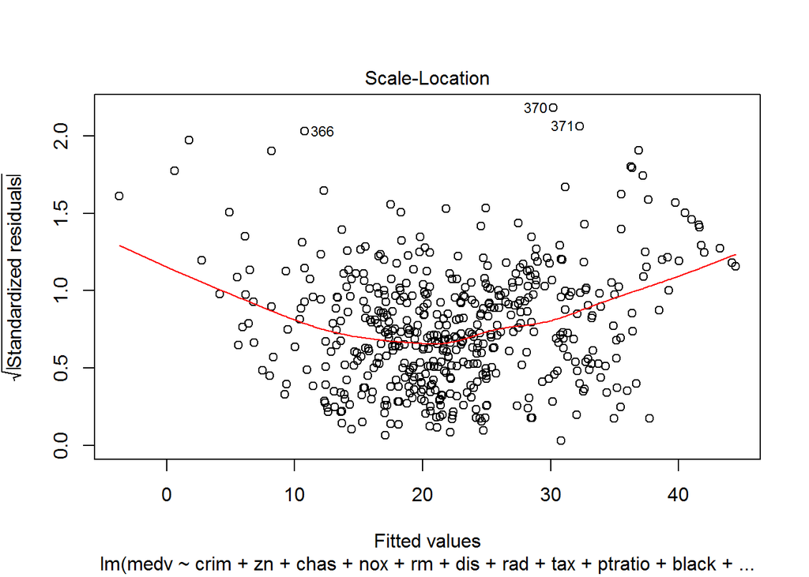

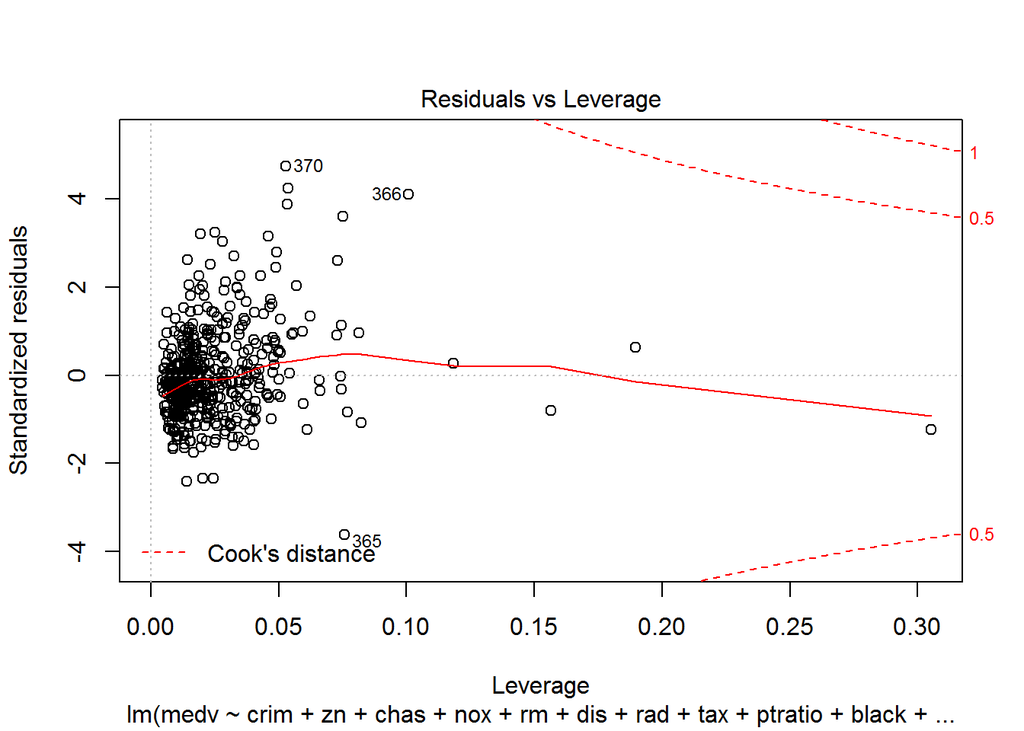

```r
plot(bk.model)
```

```r
vif(bk.model)
```

```
##     crim       zn     chas      nox       rm      dis      rad      tax
## 1.789230 2.240867 1.059664 3.769321 1.894416 3.456094 6.794954 7.173220
##  ptratio    black    lstat
## 1.751837 1.342510 2.699182
```

```r
AIC(bk.model) ; BIC(bk.model)
```

```
## [1] 2904.767
```

```
## [1] 2959.635
```

```r
step.model.f <- stepAIC(full, direction = "both", trace = FALSE)
summary(step.model.f)
```

```
##
## Call:
## lm(formula = medv ~ crim + zn + chas + nox + rm + dis + rad +
##     tax + ptratio + black + lstat, data = boston2)
##
## Residuals:
##      Min       1Q   Median       3Q      Max
## -14.9665  -2.4449  -0.5865   1.8231  19.8019
##
## Coefficients:
##               Estimate Std. Error t value Pr(>|t|)
## (Intercept)  30.313882   4.628785   6.549 1.46e-10 ***
## crim         -0.099061   0.029663  -3.340 0.000903 ***
## zn            0.039967   0.012243   3.265 0.001173 **
## chas          2.139794   0.783113   2.732 0.006514 **
## nox         -16.158058   3.199323  -5.050 6.22e-07 ***
## rm            4.488832   0.374820  11.976  < 2e-16 ***
## dis          -1.294912   0.169043  -7.660 9.97e-14 ***
## rad           0.251070   0.057538   4.364 1.56e-05 ***
## tax          -0.012243   0.003050  -4.014 6.92e-05 ***
## ptratio      -0.954242   0.116756  -8.173 2.58e-15 ***
## black         0.008678   0.002419   3.587 0.000368 ***
## lstat        -0.427210   0.043948  -9.721  < 2e-16 ***
## ---
## Signif. codes:  0 '***' 0.001 '**' 0.01 '*' 0.05 '.' 0.1 ' ' 1
##
## Residual standard error: 4.283 on 491 degrees of freedom
## Multiple R-squared:  0.7772, Adjusted R-squared:  0.7722
## F-statistic: 155.7 on 11 and 491 DF,  p-value: < 2.2e-16
```

```r
step.model.n <- stepAIC(null, direction = "both", trace = FALSE,
                       scope=list(upper=full,lower=null))
summary(step.model.n)
```

```
##
## Call:
## lm(formula = medv ~ lstat + rm + ptratio + black + dis + nox +
##     chas + zn + crim + rad + tax, data = boston2)
##
## Residuals:
##      Min       1Q   Median       3Q      Max
## -14.9665  -2.4449  -0.5865   1.8231  19.8019
##
## Coefficients:
##               Estimate Std. Error t value Pr(>|t|)
## (Intercept)  30.313882   4.628785   6.549 1.46e-10 ***
## lstat        -0.427210   0.043948  -9.721  < 2e-16 ***
## rm            4.488832   0.374820  11.976  < 2e-16 ***
## ptratio      -0.954242   0.116756  -8.173 2.58e-15 ***
## black         0.008678   0.002419   3.587 0.000368 ***
## dis          -1.294912   0.169043  -7.660 9.97e-14 ***
## nox         -16.158058   3.199323  -5.050 6.22e-07 ***
## chas          2.139794   0.783113   2.732 0.006514 **
## zn            0.039967   0.012243   3.265 0.001173 **
## crim         -0.099061   0.029663  -3.340 0.000903 ***
## rad           0.251070   0.057538   4.364 1.56e-05 ***
## tax          -0.012243   0.003050  -4.014 6.92e-05 ***
## ---
## Signif. codes:  0 '***' 0.001 '**' 0.01 '*' 0.05 '.' 0.1 ' ' 1
##
## Residual standard error: 4.283 on 491 degrees of freedom
## Multiple R-squared:  0.7772, Adjusted R-squared:  0.7722
## F-statistic: 155.7 on 11 and 491 DF,  p-value: < 2.2e-16
```

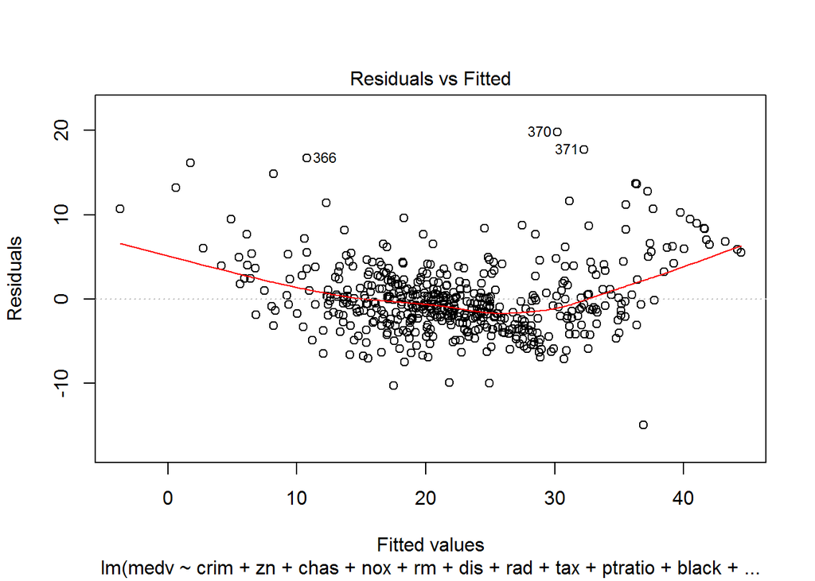

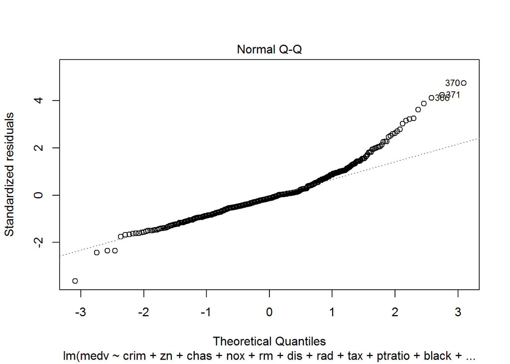

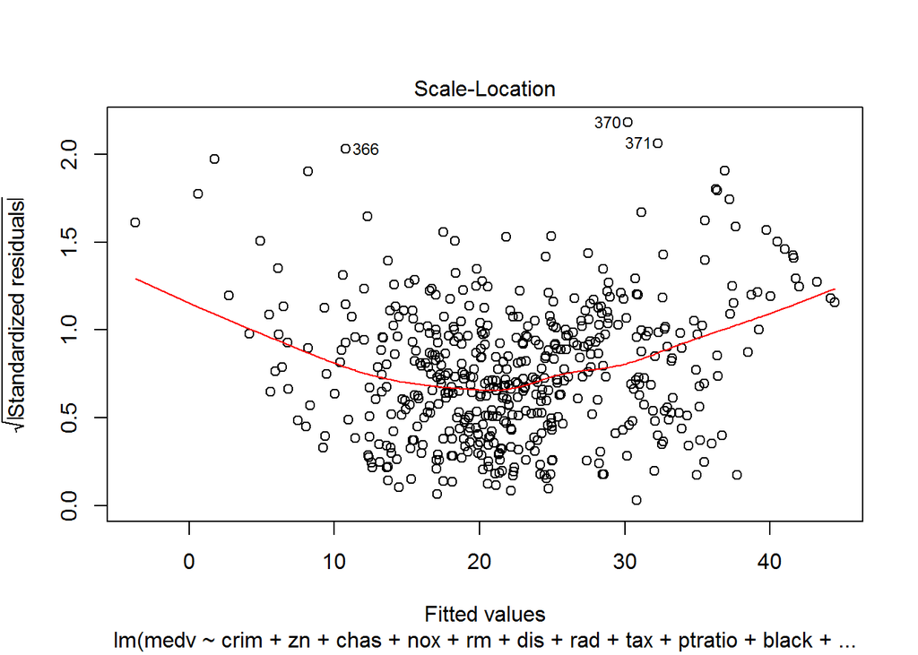

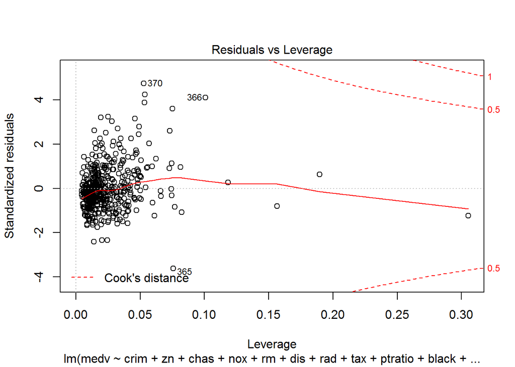

```r
step.model <- step.model.f
plot(step.model)
```

```r
vif(step.model)
```

```
##     crim       zn     chas      nox       rm      dis      rad      tax
## 1.789230 2.240867 1.059664 3.769321 1.894416 3.456094 6.794954 7.173220
##  ptratio    black    lstat
## 1.751837 1.342510 2.699182
```

```r
AIC(step.model) ; BIC(step.model)
```

```
## [1] 2904.767
```

```
## [1] 2959.635
```

### summary

| method | # of vars | adj $R^{2}$ | AIC | BIC |
| --- | --- | --- | --- | --- |
| full | 13(11) | 0.7338 | 3027.609 | 3091.007 |
| expected | 11(11) | 0.7722 | 2904.767 | 2959.635 |
| forward | 11(11) | 0.7722 | 2904.767 | 2959.635 |
| backward | 11(11) | 0.7722 | 2904.767 | 2959.635 |
| fwd/bk(adj.R) | 12(11) | 0.7723 | 2905.598 | 2964.687 |
| stepwise | 11(11) | 0.7722 | 2904.767 | 2959.635 |
| stepwise(BIC) | 10(10) | 0.7693 | 2910.358 | 2961.005 |

Thus, the final selected regression model is
$$\widehat{Y_{i}}= 30.3139 -0.0991 * crim + 0.0399 * zn + 2.1398 * chas - 16.1581 * nox + 4.4888 * rm - 1.2949 * dis + 0.2511 * rad - 0.0122 * tax - 0.9542 * ptratio + 0.0087 * black - 0.4272 * lstat$$

# cross-validation

```r
y = boston$medv
x = model.matrix(medv~., boston)[,-1]
x = scale(x)
grid = 10^seq(10, -2, length=100)

set.seed(1234)
train = sample(1:nrow(x), nrow(x)/2)
test=(-train)
y.test=y[test]
```

train data와 test data를 만들기 위해 train inddex와 test index를 random하게 선정.

# ridge regression

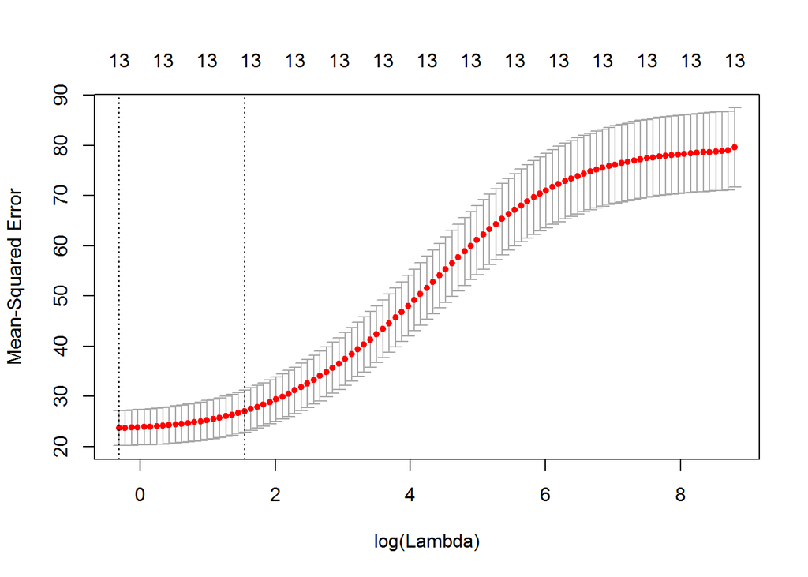

```r
rdg.cv.out = cv.glmnet(x[train,], y[train], alpha=0)
plot(rdg.cv.out)
```

```r
rdg.best.lambda = rdg.cv.out$lambda.min
rdg.best.lambda
```

```
## [1] 0.7314726
```

```r
rdg.mod <- glmnet(x[train,], y[train], alpha=0, lambda= grid)
rdg.pred <- predict(rdg.mod, s=rdg.best.lambda, newx=x[test,])

mean((rdg.pred - y.test)^2)
```

```
## [1] 26.74385
```

```r
mean((mean(y[train])-y.test)^2)
```

```
## [1] 89.72042
```

최적의 lambda 값으로 fitting한 ridge regression model의 test MSE와 null model의 test MSE 비교

# lasso regression

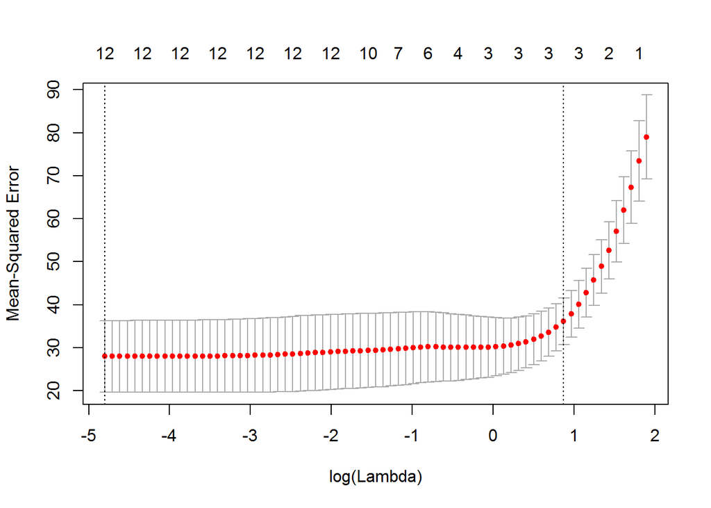

```r
las.cv.out = cv.glmnet(x[train,], y[train], alpha=1)
plot(las.cv.out)
```

```r
las.best.lambda = las.cv.out$lambda.min
las.best.lambda
```

```
## [1] 0.008216807
```

```r
las.mod <- glmnet(x[train,], y[train], alpha=1, lambda= grid)
las.pred <- predict(las.mod, s=las.best.lambda, newx=x[test,])

mean((las.pred - y.test)^2)
```

```
## [1] 25.76765
```

```r
mean((mean(y[train])-y.test)^2)
```

```
## [1] 89.72042
```

최적의 lambda 값으로 fitting한 lasso regression model의 test MSE와 null model의 test MSE 비교